# BACE: Bayesian Augmentation by Chained Equations for Comparative Biology

- Show All Code
- Hide All Code
- View Source

Author

Daniel W. A. Noble, Szymon M. Drobniak, Ayumi Mizuno, Patrice Pottier, Shinichi Nakagawa

Published

October 28, 2026

# 1 Introduction

We provide a brief introduction to the *BACE* package for Bayesian phylogenetic and correlated trait imputation. The *BACE* package allows users to impute missing data in comparative datasets using Bayesian methods that account for phylogenetic relationships among species.

# 2 When to use BACE?

General-purpose multiple-imputation tools such as **mice**, **Amelia** and **missForest** assume that rows are independent: the missing value for row *i* is imputed using the marginal distribution of the column and the observed covariates of row *i*, with no structural relationship between rows. For comparative biology datasets this assumption is wrong. Closely related species tend to share trait values because they share evolutionary history.

**BACE** keeps that information by fitting every per-variable imputation model as a Bayesian phylogenetic mixed model via `MCMCglmm`, with a phylogenetic random effect that borrows information between related taxa. Imputation is done via chained equations — one conditional model per variable with missing data — and final inference uses multiple independent imputations whose posterior draws are combined (see Section 6.5).

BACE is the right tool when:

- Your rows are species (or populations nested within species) and you have a phylogenetic tree that covers them.
- Your traits are likely to show **phylogenetic signal** — i.e. closely related species have correlated values. If you are unsure, fit a single-variable phylogenetic model to a complete trait first (e.g. `phytools::phylosig()` or an `MCMCglmm` fit with a `phylo` random effect) and check whether the phylogenetic variance component is non-trivial. We also provide a `phylo_signal_summary()` function for this very check.
- You want **posterior inference** on downstream models rather than point imputations followed by ad-hoc variance adjustments.
- Your missing-data pattern spans **mixed variable types** (continuous, binary, categorical, ordinal, count), but it of course can be used when variables are all of one type too (e.g., continuous).

BACE is probably the wrong tool when:

- Rows are independent observational units with no phylogenetic structure — generic MI tools are faster and simpler.
- The trait of interest has no detectable phylogenetic signal. The phylogenetic random effect is then noise that slows down MCMC without helping.
- Missingness is rare and plausibly MCAR — a complete-case analysis may be defensible and much easier.
- You need fast imputations. Each chained-equations iteration runs an MCMC fit, so runtimes are measured in minutes, not milliseconds.

For a broader discussion of the data-gap problem and imputation in comparative biology we recommend Dalia A. Conde et al. (2019) and Pottier et al. (2024); for Rubin’s-rules-based approaches to related problems see Nakagawa and de Villemereuil (2018).

# 3 Installation

If you encounter any issues during installation, please ensure that you have the required dependencies installed.

# 4 Documentation

The main user-facing function is `bace()`, which runs the whole imputation workflow end-to-end. Under the hood it chains four steps — `bace_imp()`, `assess_convergence()`, `bace_final_imp()` and `pool_posteriors()` — and each of those can also be called directly when you need finer control (see Section 8); for almost all analyses, though, one call to `bace()` is all you need. You can access the documentation using the following commands:

```r
?bace
```

As you will see, the function allows you to specify fixed effects, random effects, the phylogenetic tree, and other parameters for the imputation process. At the bare minimum, you need to provide a formula for the fixed effects, a formula for the random effects (including phylogeny), a phylogenetic tree, and the dataset with missing values.

At present, *BACE* only works with intercept-only phylogenetic and species-level random effects, but we are working on adding support for other types of random effects in the future (e.g., random slopes). For most comparative datasets, this will be sufficient for modeling the phylogenetic and species-level variation in the data, but not always. *BACE* is particularly powerful for when you have non-gaussian missingness as it can handle variables of all kinds of different distribution families, unlike other packages.

# 5 The BACE workflow at a glance

Fig. 1 maps the package functions onto the workflow. `bace()` is the top-level wrapper function. Internally it glues together four steps that you can also run individually when you need finer control:

1. **Initial chained imputation** — `bace_imp()`. For each variable with missing data, fit a `MCMCglmm` phylogenetic mixed model, impute the missing cells, move on to the next variable, and repeat for `runs` iterations. At each iteration the working dataset is updated on the raw scale so that later draws condition on the most recent imputations for every other variable. The first iteration warm-starts predictor NAs with marginal means (for continuous variables) or empirical draws (for categorical variables); subsequent iterations use the chained draws. Crucially, imputations in this phase are *deterministic point predictions* (posterior means / modal classes) — that is what lets the chained loop settle to a stable state.
2. **Convergence assessment of the chained loop** — `assess_convergence()`. Checks whether the *sequence of imputed datasets* has stabilised. This is not within-chain MCMC convergence — see Section 9.2. It’s useful to know whether the imputed values for each variable have settled, because the final imputation runs start from this converged dataset.
3. **Final imputation runs** — `bace_final_imp()`. Starting from the converged dataset, launch `n_final` *independent* MCMCglmm fits per variable (default `n_final = 50`; parallelisable via `n_cores`). Each run produces one complete imputed dataset and one per-variable posterior distribution. In contrast to phase 1, missing cells are re-drawn from the *posterior predictive distribution* (not a point estimate), so the returned imputed datasets differ from run to run. This between-imputation variability is what makes BACE proper multiple imputation — without it, downstream intervals would ignore missing-data uncertainty. When more than one variable has missing data, each run additionally cycles through the variables several times (the `sweeps` argument, default 3), so that every variable — including the first one in your formula — is imputed conditional on fresh random draws of the other variables rather than on fixed point estimates; only the last pass is kept. With a single incomplete variable one pass is exact, and BACE skips the extra passes automatically.
4. **Posterior pooling** — `pool_posteriors()`. Concatenate the per-imputation MCMC chains into a single set of posterior draws per parameter. These stacked draws approximate the marginal posterior of the analysis model integrating over the imputation distribution.

`bace()` runs all four steps and additionally retries step 1 with more chained iterations if step 2 fails (up to `max_attempts` times). As Fig. 1 shows, there is also a second, model-agnostic route from step 3’s imputed datasets to pooled inference: fit *any* downstream model to each imputed dataset with `with_imputations()` and combine the estimates with Rubin’s rules via `pool_mi()` — see Section 7. The rest of this vignette walks through the workflow first with `bace()` and then shows how to run each step individually.

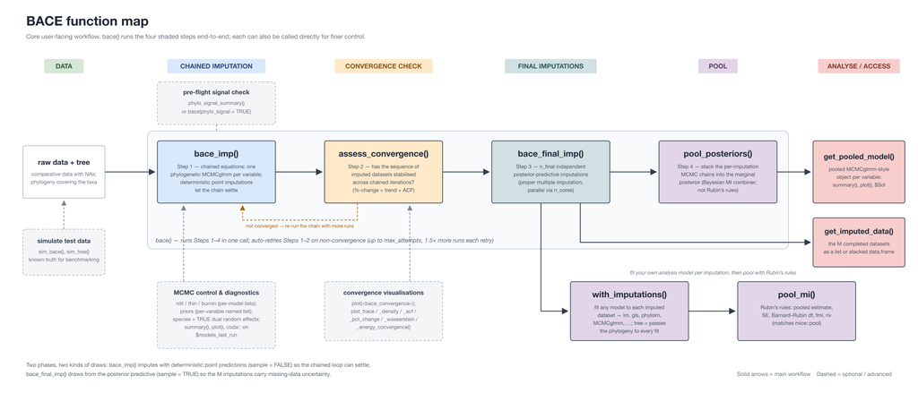

Figure 1— Core user-facing BACE function map. Solid arrows show the main workflow from raw comparative data through chained imputation (`bace_imp()`), chained-loop convergence checking (`assess_convergence()`), posterior-predictive final imputations (`bace_final_imp()`), and posterior pooling (`pool_posteriors()`), with accessors (`get_pooled_model()`, `get_imputed_data()`) reading the finished object. The light band marks the steps orchestrated by the `bace()` wrapper, including its automatic retry of the chained phase on non-convergence. The lower-right branch is the alternative Rubin’s-rules pathway: `with_imputations()` fits any downstream model to each imputed dataset and `pool_mi()` combines the estimates. Dashed boxes and arrows show optional or advanced routes: simulating benchmark data (`sim_bace()`), pre-flight phylogenetic-signal checks (`phylo_signal_summary()`), per-model MCMC control and diagnostics, and the convergence-plot family.

# 6 Example Usage

## 6.1 Simulating Data

We’ll first simulate a dataset with missing values and a phylogenetic tree. We can do this using the `sim_bace()` function.

```r
# Set seed for reproducibility
set.seed(123)

# Simulate data. Note that threshold4 indicates an ordinal variable with 4 levels, and multinomial3 indicates a categorical variable with 3 levels. You can replace the numbers
sim_data <- sim_bace(response_type = "poisson",
                   predictor_types = c("gaussian", "binary", "threshold4", "multinomial3"),
                      phylo_signal = c(0.55, 0.75, 0.8, 0.7, 0.7),
                       missingness = c(0.2, 0.3, 0.4, 0.2, 0.5),
                           n_cases = 100,
                         n_species = 100)
```

```
Generated default beta_matrix with pre-set sparsity
```

```
Generated default beta_resp: -0.043, 0.457, -0.047, 0.178
```

We can then view the simulated data and phylogenetic tree because the `sim_bace()` function returns a list containing both objects. It also has a lot of other useful information about the simulation users can explore.

```r
# Object contains both the simulated data and phylogeny
    data <- sim_data$data
    tree <- sim_data$tree

# View first few rows of the data
    head(data)
```

```
  Species  y          x1   x2   x3   x4
1   pJUhd NA -2.72232649 <NA>    3 <NA>
2   h62z2 NA  0.07569633 <NA> <NA> <NA>
3   69Haj  0 -3.04527643 <NA> <NA>    B
4   gv77g  3          NA <NA>    3    C
5   Arhl9  2 -1.78548552 <NA>    3    A
6   wLS5r  0          NA    0    2 <NA>
```

Here, we can see that the dataset contains lots of missing values across different variable types. Of course, normally, we would need to exclude these cases to use a complete dataset. However, with *BACE* we simply feed in the entire dataset, specify the models we want to use for imputation (or the real model of interest), and impute the missing data.

## 6.2 Pre-flight: check phylogenetic signal

Before committing to a full BACE run (which can take minutes to hours for larger datasets), it’s worth checking whether the variables carry enough phylogenetic information for the phylogenetic random effect to help imputation. BACE provides `phylo_signal_summary()`, which fits one univariate phylogenetic mixed model per variable and reports:

- **H²** — phylogenetic heritability (fraction of variance attributable to the phylogeny) on the latent scale that BACE’s per-variable models actually operate on. Posterior mean + 95% HPD. Works for **all** variable types (gaussian, poisson, binary, ordered, multinomial).
- **λ, K** (continuous variables only) — Pagel’s (Pagel 1999) and Blomberg’s (Blomberg, Garland, and Ives 2003) classical statistics, via `phytools::phylosig()`.
- **D** (binary variables only) — Fritz-Purvis D (Fritz and Purvis 2010), via `caper::phylo.d()`.
- **Convergence flags** — every fit is checked with `coda::effectiveSize()` and `coda::geweke.diag()`; rows with low effective sample size or failed Geweke tests are flagged `unreliable` and marked with an asterisk in the printout. Do not interpret flagged rows as data-driven estimates.

The same H² formulas that BACE’s own per-variable models imply are used here, so the number is directly informative about the imputation model’s structure. The function automatically updates these statistics depending on BACE’s two-RE modes: `species = FALSE` fits a single phylogenetic random effect; `species = TRUE` fits the dual structure (phylogenetic + non-phylogenetic species) which BACE uses when there are within-species replicates.

```r
# Quick first-pass signal check using quick = TRUE (halves iterations):
signal <- phylo_signal_summary(
  data        = data,
  tree        = tree,
  species_col = "Species",
  species     = FALSE,
  quick       = TRUE
)
print(signal)
```

```
=============================================================
  Phylogenetic signal summary
=============================================================
  Random-effect structure: single (phylo only)
  Variables                : 5

--- Warnings ---
  [quick_mode] quick = TRUE: nitt and burnin halved. Expect more low_ess flags.

--- Table ---
 variable        type n_obs H2_mean    H2_lo H2_hi   lambda      K     D
        y     poisson    80  0.125* 5.89e-08 0.509 7.35e-05 0.0669    NA
       x1    gaussian    70  0.713* 4.89e-01 0.904 6.93e-01 0.0665    NA
       x2   threshold    60  0.728* 4.34e-02 0.999       NA     NA 0.746
       x3   threshold    80  0.998* 9.95e-01 1.000       NA     NA    NA
       x4 categorical    50  0.764* 3.07e-01 0.982       NA     NA    NA
 min_ess interpretation                           flag
  178.60            low low_ess;geweke_fail;unreliable
  750.00           high             low_ess;unreliable
    3.51           high             low_ess;unreliable
    3.73           high             low_ess;unreliable
   46.43           high low_ess;geweke_fail;unreliable

Interpretation bands: H2 < 0.2 = low, 0.2-0.5 = moderate, >0.5 = high.
Flag meanings:
  low_ess     -- effective sample size below threshold (default 1000)
  geweke_fail -- Geweke diagnostic |z| > 2 on any variance component
  unreliable  -- H2 cell should NOT be trusted (low_ess or geweke_fail)
  low_n       -- n_obs < 20; posterior is data-sparse
  fit_error   -- MCMCglmm fit failed (check warnings)

Note: phylogenetic signal is necessary but NOT sufficient for good
imputation. A high-H2 trait can still impute poorly under MNAR missingness;
a low-H2 trait can still impute well if coupled to an observed predictor.
```

Or, more concisely, call `bace()` with `phylo_signal = TRUE` to get the same diagnostic without running the imputation pipeline:

```r
# Signal-only preview: returns the same phylo_signal table as above and
# does NOT run the imputation pipeline (so we don't evaluate it twice here).
preview <- bace(
  fixformula     = y ~ x1 + x2 + x3 + x4,
  ran_phylo_form = ~ 1 | Species,
  phylo          = tree,
  data           = data,
  phylo_signal   = TRUE
)
```

**How to interpret the table:**

- H² < 0.2 = **low** signal — the phylogenetic random effect contributes little for this variable; imputation will rely mostly on observed predictors.
- 0.2 ≤ H² < 0.5 = **moderate** signal.
- H² ≥ 0.5 = **high** signal — the phylogenetic random effect carries substantial information; BACE’s phylogenetic structure is expected to help.

**Important**

Phylogenetic signal is *necessary but not sufficient* for good imputation. A high-H² trait can still impute poorly if the data are missing-not-at-random (MNAR); a low-H² trait can still impute well if it is tightly coupled to an observed predictor. The signal table sets expectations; it does not predict imputation accuracy.

If you have weak phylogenetic signal in some variables all is not lost so long as you have auxillary variables you can include in the imputation model.

## 6.3 Using *BACE* for Imputation

Now that we have the data and the phylogenetic tree we can run the imputation. For almost all users this means a single call to `bace()`; the sub-functions such as `bace_imp()` exist for finer stepwise control and are covered in Section 8.

**Caution**

It’s very important to ensure that all variables are correctly classified in the dataset (e.g., factors for categorical variables, numeric for continuous variables, etc.) before running the imputation. *BACE* will fit different models for different variable types, and so, if they have not been correctly classified you will be modeling the variable incorrectly.

*BACE* decides the imputation family for each variable deterministically from how the column is stored:

| Stored as | Detected type | Imputation model |
| --- | --- | --- |
| numeric (double) | gaussian | Gaussian phylogenetic mixed model |
| integer, all values ≥ 0 | count | Poisson (log link), count-specific priors |
| integer with negative values | gaussian | treated as integer-coded continuous |
| factor with 2 levels | binary | binary threshold (probit) model |
| ordered factor with ≥ 3 levels | ordinal | ordinal threshold model |
| unordered factor with ≥ 3 levels | categorical | multinomial probit model |

Two consequences of these rules deserve emphasis:

- **Integer storage means counts.** A column stored as `integer` whose values are all non-negative is imputed as a Poisson count. If you have an integer-*coded* variable that is really continuous (e.g. body mass recorded to the nearest gram), store it as a double (`as.numeric()`) before running *BACE*. Conversely, true counts must be stored as integers to get the Poisson model.
- **Unordered factors with ≥ 3 levels get a true multinomial probit model** by default (`ovr_categorical = FALSE`). Setting `ovr_categorical = TRUE` instead fits one-vs-rest binary threshold models per category — this is retained for backwards compatibility, but the multinomial parameterisation is both better calibrated and substantially faster in our simulations, so we recommend the default.

If you want to see what *BACE* has classified each variable as, you can inspect the `types` element of any fitted `bace_imp()` or `bace()` object. For example, after running the simple workflow below you can do:

```r
# After running bace() (see next section), inspect the inferred variable types
bace_final1$initial_results$types
```

Importantly, users also need to think carefully about the distributions of the variables themselves and transform them if necessary prior to running `bace_imp` (e.g., log-transforming skewed continuous variables).

There are two ways you can use `bace/bace_imp`. The first is to specify a list of all the formulas for each variable you would like to fit. It is important here that, if you provide a list, that **any variable with missing data is found as a response variable**. This must be the case because *BACE* will not automatically build models for other variables if you provide a list of formulas (but see below).

For now, we’ll focus on the simplified `bace` workflow because it does the full process for you, but later we will show how different components of the workflow can be run separately for more control over the imputation process.

## 6.4 Simple BACE Workflow

The `bace()` function is the main function to conduct a *BACE* analysis running each of the core steps: 1) initial imputations to reach convergence in imputed data; 2) convergence assessment to ensure that imputed data has reached a stable state; 3) imputing missing data `n_final` times (50 by default) by drawing from the posterior predictive distribution of the final models, re-fitting and estimating parameters and then pooling posteriors across the final runs.

If convergence is not achieved, it will automatically restart the initial steps to allow chains to converge before running the final set of models. You can also specify the number of runs, MCMC parameters, and whether to plot the results. The final output will include pooled models that account for imputation uncertainty.

```
=======================================================
BACE: Bayesian Analysis with Chained Equations
=======================================================

Step 1: Initial imputation for convergence assessment
-------------------------------------------------------
Run 1, Imputed variable: y
Run 1, Imputed variable: x1
Run 1, Imputed variable: x2
Run 2, Imputed variable: y
Run 2, Imputed variable: x1
Run 2, Imputed variable: x2
Run 3, Imputed variable: y
Run 3, Imputed variable: x1
Run 3, Imputed variable: x2
Run 4, Imputed variable: y
Run 4, Imputed variable: x1
Run 4, Imputed variable: x2
Run 5, Imputed variable: y
Run 5, Imputed variable: x1
Run 5, Imputed variable: x2
Run 6, Imputed variable: y
Run 6, Imputed variable: x1
Run 6, Imputed variable: x2
Run 7, Imputed variable: y
Run 7, Imputed variable: x1
Run 7, Imputed variable: x2
Run 8, Imputed variable: y
Run 8, Imputed variable: x1
Run 8, Imputed variable: x2
Run 9, Imputed variable: y
Run 9, Imputed variable: x1
Run 9, Imputed variable: x2
Run 10, Imputed variable: y
Run 10, Imputed variable: x1
Run 10, Imputed variable: x2
Run 11, Imputed variable: y
Run 11, Imputed variable: x1
Run 11, Imputed variable: x2
Run 12, Imputed variable: y
```

[output cut: 33 more lines]

```
  Consider increasing nitt, adjusting priors, or checking model specification

Convergence by Response Variable:
----------------------------------------
[~] y              :  3/ 5 parameters good
[CH] x1             :  3/ 5 parameters good
    Check convergence: Species, units
[CH] x2             :  0/ 4 parameters good (1 fixed)
    Check convergence: (Intercept), x1, y, Species
========================================



Step 2: Convergence assessment
-------------------------------------------------------
```

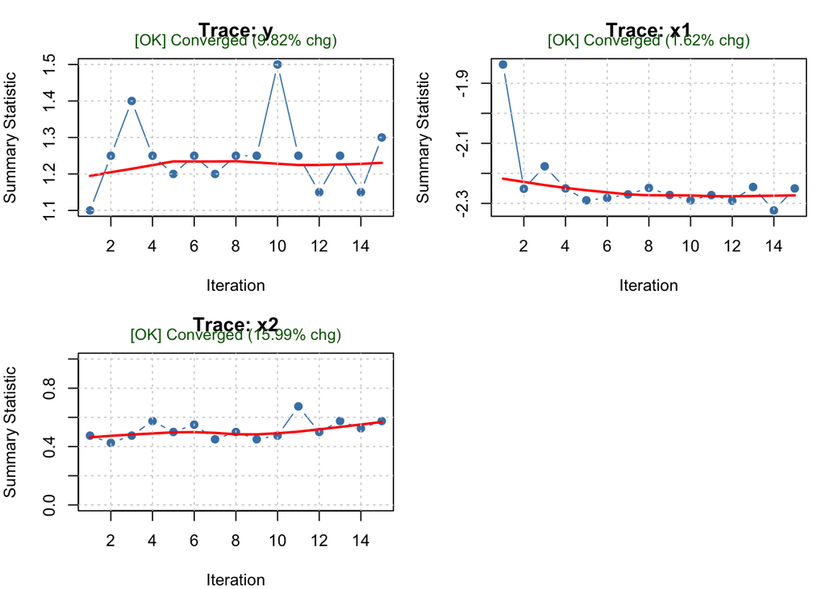

```
Step 3: Final imputation runs for posterior pooling
-------------------------------------------------------

=== Running 10 final imputation iterations ===

Run 1/10 (sweep 1/3) - Imputed variable: y
Run 1/10 (sweep 1/3) - Imputed variable: x1
Run 1/10 (sweep 1/3) - Imputed variable: x2
Run 1/10 (sweep 2/3) - Imputed variable: y
Run 1/10 (sweep 2/3) - Imputed variable: x1
Run 1/10 (sweep 2/3) - Imputed variable: x2
Run 1/10 (sweep 3/3) - Imputed variable: y
Run 1/10 (sweep 3/3) - Imputed variable: x1
Run 1/10 (sweep 3/3) - Imputed variable: x2
Run 2/10 (sweep 1/3) - Imputed variable: y
Run 2/10 (sweep 1/3) - Imputed variable: x1
Run 2/10 (sweep 1/3) - Imputed variable: x2
Run 2/10 (sweep 2/3) - Imputed variable: y
Run 2/10 (sweep 2/3) - Imputed variable: x1
Run 2/10 (sweep 2/3) - Imputed variable: x2
Run 2/10 (sweep 3/3) - Imputed variable: y
Run 2/10 (sweep 3/3) - Imputed variable: x1
Run 2/10 (sweep 3/3) - Imputed variable: x2
Run 3/10 (sweep 1/3) - Imputed variable: y
Run 3/10 (sweep 1/3) - Imputed variable: x1
Run 3/10 (sweep 1/3) - Imputed variable: x2
Run 3/10 (sweep 2/3) - Imputed variable: y
Run 3/10 (sweep 2/3) - Imputed variable: x1
Run 3/10 (sweep 2/3) - Imputed variable: x2
Run 3/10 (sweep 3/3) - Imputed variable: y
Run 3/10 (sweep 3/3) - Imputed variable: x1
Run 3/10 (sweep 3/3) - Imputed variable: x2
Run 4/10 (sweep 1/3) - Imputed variable: y
Run 4/10 (sweep 1/3) - Imputed variable: x1
Run 4/10 (sweep 1/3) - Imputed variable: x2
Run 4/10 (sweep 2/3) - Imputed variable: y
Run 4/10 (sweep 2/3) - Imputed variable: x1
Run 4/10 (sweep 2/3) - Imputed variable: x2
Run 4/10 (sweep 3/3) - Imputed variable: y
Run 4/10 (sweep 3/3) - Imputed variable: x1
```

[output cut: 75 more lines]

```
Pooled 3 variable model(s) across 10 imputations

=======================================================
BACE Analysis Complete!
=======================================================

Convergence achieved: TRUE
Number of attempts: 1
Final imputations: 10

Access results via:
  - $pooled_models: Pooled posterior distributions
  - $imputed_datasets: List of 10 imputed datasets
  - $convergence: Convergence diagnostics
  - $final_results: Full final imputation results
```

```r
# Run the full bace workflow. Note: we set n_final = 10 here only to keep this
# vignette quick to build; for real analyses the default (n_final = 50) is a
# better choice (see the n_final bullet below).
bace_final1 <- bace(fixformula = "y ~ x1 + x2",
                     ran_phylo_form = "~ 1 | Species",
                              phylo = tree,
                               data = data,
                               species = FALSE,
                               runs = 15, nitt = 100000, burnin = 10000, thin = 10, n_final = 10, plot = TRUE, skip_conv = FALSE, sample_size = 1000)
```

We can now check what *BACE* classified each variable as to just make sure they have been modelled correctly:

```r
# The variable types inferred by BACE for our simulated data
bace_final1$initial_results$types
```

```
$y
[1] "poisson"

$x1
[1] "gaussian"

$x2
[1] "threshold"
```

As we can see `bace` provides a comprehensive overview of the imputation process including each of the core steps. This includes the initial set of runs to allow data to converge, followed by convergence assessment checks both across runs and within parameters of models.

**Note**

If convergence is not achieved, the function will automatically restart the initial steps to allow chains to converge before running the final set of models. However, users should be aware that the check can sometimes fail even when convergence has likely been achieved. If you think this is the case then you can do the initial runs and skip the convergence assessment (see below). It is also not always the case that parameter checks signal problems with the models. Users will need to explore final models carefully before adjusting MCMC parameters or the number of runs. More on this below.

It’s worth highlighting a few key arguments within `bace`.

Once the imputation is complete, you can access the final pooled models and evaluate them as you would any `MCMCglmm` model for each of the models fit. This is important for checking model fit and convergence along with downstream inference. For example, you can check the summary of the model for the response variable `y` as follows:

```r
# Extract the pooled model for the response variable using get_pooled_model()
y_model <- get_pooled_model(bace_final1, variable = "y")
summary(y_model)
```

```
+----------------------------------------------------------------+
|  BACE Pooled MCMCglmm summary (stacked per-imputation draws)    |
+----------------------------------------------------------------+

Stacked from 10 imputations
Total posterior draws: 10000
  (= 1000 sampled per imputation x 10 imputations)
  Original samples per imputation: 9000

Posterior summaries below are computed from stacked draws that
approximate p(theta | Y_obs) (Monte Carlo integration over imputed
values). Validity requires each per-imputation chain to have
converged on its own; check a subset via
plot(final$all_models[[1]]$<var>) and coda::effectiveSize().
----------------------------------------------------------------


 Iterations = 1:10000
 Thinning interval  = 1
 Sample size  = 10000

 DIC: 257.6983

 G-structure:  ~Species

        post.mean  l-95% CI u-95% CI eff.samp
Species    0.1096 1.106e-08   0.4492     9548

 R-structure:  ~units

      post.mean l-95% CI u-95% CI eff.samp
units    0.5067  0.07734   0.9672     1688

 Location effects: y ~ x1 + x2

            post.mean l-95% CI u-95% CI eff.samp pMCMC
(Intercept)   0.06241 -0.38314  0.49030  1645.96 0.720
x1           -0.02012 -0.32049  0.28775   287.36 0.886
x2.L          0.52301  0.06323  0.97196    90.42 0.019 *
---
Signif. codes:  0 '***' 0.001 '**' 0.01 '*' 0.05 '.' 0.1 ' ' 1
```

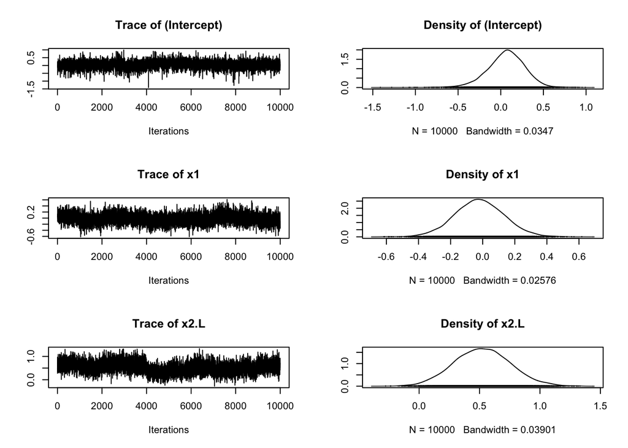

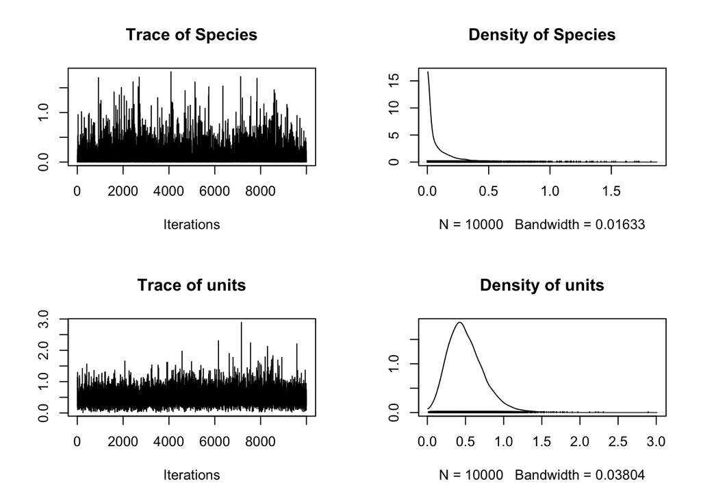

```r
plot(y_model)
```

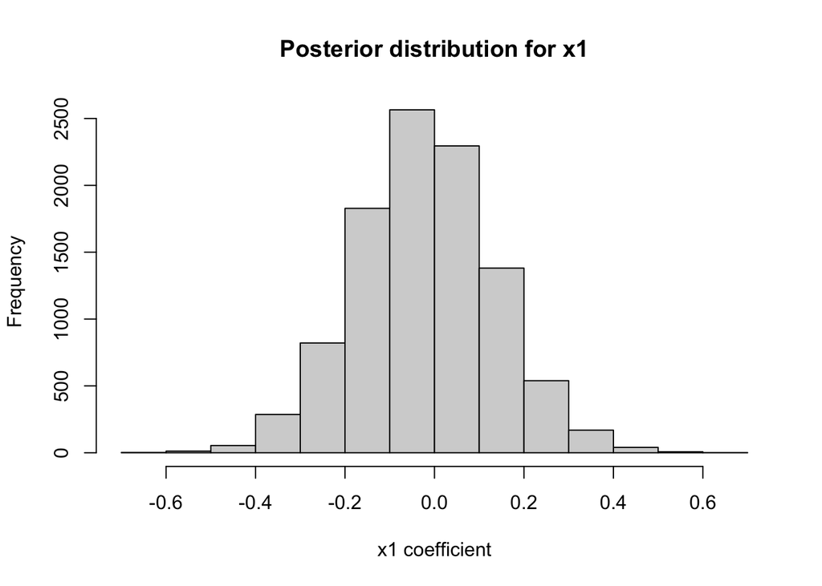

```r
# We can now extract posteriors in the same way we would use a normal MCMCglmm model, but now we have the pooled results that account for imputation uncertainty. For example, we can extract the posterior samples for the fixed effects as follows:

hist(y_model$Sol[, "x1"], main = "Posterior distribution for x1", xlab = "x1 coefficient")
```

```r
# The same accessor without the 'variable' argument returns the full named
# list of pooled models (one per imputed variable) - so all_models$y is
# identical to y_model above.
all_models <- get_pooled_model(bace_final1)
names(all_models)
```

```
[1] "y"  "x1" "x2"
```

The banner above reports whether the chained loop passed the convergence check (and, if not, how many retry attempts `bace()` made). Whatever the banner says, it is worth looking at the trace and density plots of the pooled `MCMCglmm` models: variance components in particular can mix slowly, and if they look poorly converged it’s best to adjust the `bace` MCMC parameters (`nitt`, `burnin`, `thin`) to allow for longer runtimes and better mixing before trusting downstream inference.

Another important feature is that users can also access all the final datasets with imputed values for each run. This can be useful for checking the imputed values (i.e., cross-validation) and exploring the imputation process in more detail. You can access the imputed datasets using the `get_imputed_data()` function, which returns them as either a list or a single stacked data frame:

```r
# Access the imputed datasets as a list (one data frame per imputation run)
imputed_datasets <- get_imputed_data(bace_final1, format = "list")
length(imputed_datasets)
```

```
[1] 10
```

```r
head(imputed_datasets[[1]])
```

```
  y          x1 x2 Species
1 1 -2.72232649  0   pJUhd
2 4  0.07569633  0   h62z2
3 0 -3.04527643  1   69Haj
4 3 -4.14199517  1   gv77g
5 2 -1.78548552  1   Arhl9
6 0  0.55217341  0   wLS5r
```

```r
# Or stack all imputed datasets into one data frame with an .imputation column
imputed_df <- get_imputed_data(bace_final1, format = "data.frame")
table(imputed_df$.imputation)
```

```
  1   2   3   4   5   6   7   8   9  10
100 100 100 100 100 100 100 100 100 100
```

## 6.5 Interpreting the pooled output

It is worth being precise about what the pooled posterior returned by `bace()` actually is, because the terminology in the multiple-imputation literature can be confusing.

`pool_posteriors()` **concatenates** the MCMC draws from the `n_final` per-imputation fits into a single set of draws per parameter. Each per-imputation chain targets the *conditional* posterior $p(\theta \mid Y_{\text{obs}}, Y_{\text{mis}}^{(m)})$, where $Y_{\text{mis}}^{(m)}$ is the m-th complete imputed dataset. Stacking these chains is an approximation to the *marginal* posterior
$$p(\theta \mid Y_{\text{obs}}) = \int p(\theta \mid Y_{\text{obs}}, Y_{\text{mis}})\, p(Y_{\text{mis}} \mid Y_{\text{obs}})\, dY_{\text{mis}},$$
which integrates over uncertainty in the imputed values as well as over parameter uncertainty. Posterior summaries — means, quantiles, HPD intervals — computed from the stacked draws therefore reflect both sources of uncertainty simultaneously. This is the standard Bayesian-MI combiner; see Zhou and Reiter (2010) and Chapter 18 of Gelman et al. (2013).

Two practical notes follow from this:

1. **This is not Rubin’s rules.** Rubin’s rules combine *scalar* point estimates and variances from each imputation using a specific within/between-imputation variance decomposition. *BACE* does provide a Rubin’s-rules pathway if desired — `with_imputations()` + `pool_mi()` — see Section 7.
2. **Validity depends on per-imputation MCMC convergence.** Because each per-imputation chain is supposed to target its own conditional posterior, the stacked draws inherit any bias from chains that have not converged. Before trusting pooled summaries, spot-check a handful of the per-imputation fits with standard diagnostics. For example:

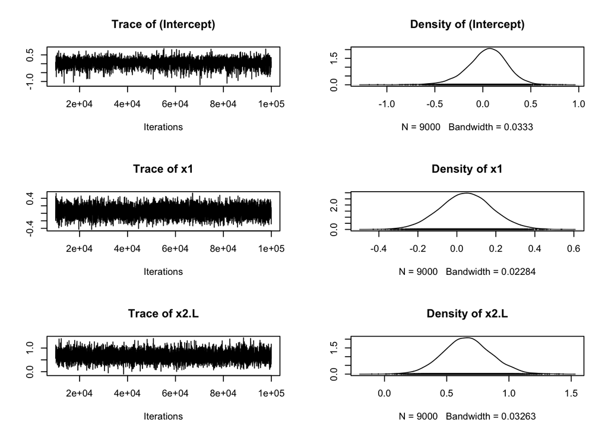

```r
# Inspect MCMC diagnostics on the first per-imputation fit for 'y'.
# Sol also stores a sample for every species-level effect (pr = TRUE),
# so we restrict the output to the fixed effects (the first nfl columns);
# drop the subsetting to inspect every parameter.
first_fit  <- bace_final1$final_results$all_models[[1]]$y
fixed_sols <- coda::as.mcmc(first_fit$Sol[, 1:first_fit$Fixed$nfl, drop = FALSE])
plot(fixed_sols)
```

```r
coda::effectiveSize(fixed_sols)
```

```
(Intercept)          x1        x2.L
   3407.018    5199.212    3874.261
```

```r
coda::autocorr.diag(fixed_sols)
```

```
        (Intercept)           x1         x2.L
Lag 0    1.00000000  1.000000000 1.000000e+00
Lag 10   0.27232137  0.223192668 3.102074e-01
Lag 50   0.04301813 -0.002202535 1.445306e-02
Lag 100  0.01242483  0.014935373 3.519735e-02
Lag 500  0.01843817  0.014438562 7.525545e-05
```

**How to read this output.** The trace plots should look like fuzzy caterpillars with no drift or sticky patches, and the density plots should be smooth and unimodal. `effectiveSize()` reports how many *independent* draws the autocorrelated chain is worth: values close to the number of stored samples indicate good mixing, while values below a few hundred mean the posterior summaries for that parameter are unstable and the chain should be run longer. `autocorr.diag()` should drop towards zero within a few lags; values that stay high at large lags are the same warning in a different form. If these look poor, increase `nitt` and/or `burnin` and re-run `bace()` rather than simply trusting the pooled banner.

# 7 Downstream analysis with Rubin’s rules

The pooled `MCMCglmm` models returned by `bace()` are the imputation models themselves. Often, though, the model you actually care about is a *different* downstream analysis — a phylogenetic GLS on the completed data, a GLM with a different predictor set, a `phylolm` fit — and you want that analysis to propagate imputation uncertainty. This is the classical multiple-imputation setting, and *BACE* supports it directly with two functions (the lower-right branch of Fig. 1):

1. `with_imputations(object, .f)` applies your model-fitting function `.f` to **each** of the `n_final` imputed datasets and returns the list of fits. It accepts the output of `bace()` or `bace_final_imp()` (or a plain list of completed data frames), shows progress, and captures per-fit errors rather than aborting the whole loop.
2. `pool_mi(fits)` combines the per-imputation coefficient estimates with **Rubin’s rules** (Rubin 1987): the pooled variance is the within-imputation variance plus (1 + 1/M) times the between-imputation variance, degrees of freedom use the Barnard and Rubin (1999) small-sample correction when the complete-data residual df is available, and the output reports the fraction of missing information (`fmi`) and relative increase in variance (`riv`) per coefficient. The implementation matches `mice::pool` to machine precision on identical inputs.

Continuing with the `bace_final1` object fitted above (recall `y` is a count):

```r
# 1. Fit a downstream GLM to each imputed dataset
fits <- with_imputations(bace_final1,
                         function(d) glm(y ~ x1 + x2, family = poisson, data = d))

# 2. Pool with Rubin's rules
pool_mi(fits)
```

```
Pooled estimates from 10 imputations (Rubin's rules)
Confidence level: 95%

        term estimate std.error    df statistic   p.value conf.low conf.high
 (Intercept)   0.3110    0.1447 52.69     2.148   0.03631  0.02059    0.6013
          x1 -0.01887   0.04952 25.52   -0.3811    0.7063  -0.1208   0.08301
        x2.L   0.4787    0.1387 273.1     3.451 0.0006462   0.2056    0.7517
    fmi    riv
 0.4344 0.7044
 0.6223  1.462
 0.1874 0.2218

Note: max fmi = 0.62. Consider more imputations for stable SEs.
```

Each row gives the pooled estimate, standard error, Barnard–Rubin degrees of freedom, confidence interval, and the `fmi`/`riv` diagnostics. High `fmi` for a coefficient means much of its uncertainty comes from the missing data itself — a useful, standard MI diagnostic that the stacked-posterior pathway does not report.

Because `with_imputations()` is model-agnostic, phylogenetic downstream models work too. If your function declares a `tree` argument, the phylogeny supplied to `with_imputations()` is passed through to every fit:

```r
# Phylogenetic GLS on each imputed dataset, pooled with Rubin's rules
fits_gls <- with_imputations(
  bace_final1,
  function(d, tree) {
    nlme::gls(y ~ x1 + x2, data = d,
              correlation = ape::corBrownian(phy = tree, form = ~Species))
  },
  tree = tree
)
pool_mi(fits_gls)
```

**When to use which combiner:**

- **`pool_posteriors()` (stacking)** — when the per-imputation analysis is Bayesian (`MCMCglmm`) and you want full marginal posteriors. No normality assumption; the right choice for variance components, phylogenetic signal, and heritability, whose posteriors are skewed and bounded.
- **`pool_mi()` (Rubin’s rules)** — when the per-imputation analysis is frequentist, or when you want the standard MI reporting apparatus (pooled SEs, df, `fmi`). It assumes the per-imputation estimates are approximately normal, which is reasonable for fixed-effect coefficients but **not** for variance components — never pool variance components, phylogenetic signal, or heritability with `pool_mi()`; use `pool_posteriors()` for those.

`pool_mi()` will also accept `MCMCglmm` fits (it takes the posterior mean and covariance of the fixed effects as the per-imputation estimate and variance), which is convenient for computing `fmi` on a Bayesian analysis — but for coefficient inference from `MCMCglmm` fits, stacking remains the principled combiner. For the general theory see Rubin (1987) and Chapter 2 of van Buuren (2018).

# 8 Advanced: running the workflow step by step

For most users `bace()` is the right entry point — it runs the four-step workflow end-to-end and retries if the chained loop has not converged. But there are cases where you want finer control: you may want to skip convergence assessment, inspect intermediate objects, run more or fewer final imputations than the default, or substitute your own pooling step. Here we show how to call `bace_imp()`, `bace_final_imp()` and `pool_posteriors()` directly.

## 8.1 Controlling the imputation models with a list of formulas

The first thing you might want to control is which model is fit for each variable with missing data. `bace()` and `bace_imp()` both accept a *list* of formulas, one per variable with missing data. This is useful when you want different predictors for different variables (for example, when a variable should only be imputed from a subset of the others, or when you want to include an interaction in one model but not another).

Note that if you pass a list, every variable with missing data must appear as a response somewhere in the list — *BACE* will not auto-generate models for variables you have left out.

```r
# First check that all variables are correctly classified. If using sim_bace() this is done automatically, but always worth checking.
  str(data)

# Perform BACE imputation. Here we specify models for each variable in the dataset.
bace_impute <- bace_imp(fixformula = list("y ~ x1 + x2",
                                          "x1 ~ x2",
                                          "x2 ~ x4",
                                          "x3 ~ x1 + x2",
                                          "x4 ~ x1 + x2"),
                    ran_phylo_form = "~ 1 | Species",
                             phylo = tree,
                              data = data,
                              runs = 5, verbose = FALSE)
```

What *BACE* will do here is fit a `MCMCglmm` model for each of the response variables specified in the formula list. At the first iteration, it will fill in missing values for any predictors using either their mean (for continuous variables) or randomly sampled values (for categorical variables). Models will then be fit using this complete predictor set and predictions will be made for missing values of the response variable.

In the next run, model predictions will be used to ‘fill’ in missing values in any predictors instead. This cycle will continue until the predicted values converge. This process is repeated for the number of iterations specified by the `runs` argument. All the models will include the phylogenetic random effect specified in the `ran_phylo_form` argument.

The second way to use *BACE* is to just provide a model with your main variables. This may be because you have an *a priori* model in mind. As such, you can also simply feed in a single formula as below. Here, *BACE* will automatically build models for the other variables based on their types and the variables present in the dataset. It will impute missing values in the same way as described above, but using all other variables as predictors. You can also specify interactions if you wish. We can run *BACE* in this way as follows (this time using verbose = TRUE to see more output during the imputation process):

```r
# Fit BACE with a single formula
bace_impute2 <- bace_imp(fixformula = "y ~ x1 + x2",
                     ran_phylo_form = "~ 1 | Species",
                              phylo = tree,
                               data = data,
                               runs = 5, nitt = 20000, burnin = 5000, thin = 10)
```

```
Run 1, Imputed variable: y
Run 1, Imputed variable: x1
Run 1, Imputed variable: x2
Run 2, Imputed variable: y
Run 2, Imputed variable: x1
Run 2, Imputed variable: x2
Run 3, Imputed variable: y
Run 3, Imputed variable: x1
Run 3, Imputed variable: x2
Run 4, Imputed variable: y
Run 4, Imputed variable: x1
Run 4, Imputed variable: x2
Run 5, Imputed variable: y
Run 5, Imputed variable: x1
Run 5, Imputed variable: x2

========================================
BACE MCMC Diagnostics Summary
========================================

Number of models: 3
Total parameters: 15
  Fixed effects: 9
  Variance components: 6
  Fixed units (threshold/categorical): 1

Mean Effective Sample Size:
  Fixed effects:      780.5
  Variance components: 477.8

Convergence Assessment:
  Check       :   6 parameters (40.0%)
  Fixed       :   1 parameters (6.7%)
  Good        :   8 parameters (53.3%)

Overall: CHECK - Many parameters show convergence issues
  Consider increasing nitt, adjusting priors, or checking model specification

Convergence by Response Variable:
----------------------------------------
[CH] y              :  3/ 5 parameters good
    Check convergence: Species, units
[OK] x1             :  5/ 5 parameters good
[CH] x2             :  0/ 4 parameters good (1 fixed)
    Check convergence: (Intercept), x1, y, Species
========================================
```

As you can see from the printout above, *BACE* provides a summary of the imputation process, including the number of models fitted, parameters estimated, and effective sample sizes which evaluate how well the MCMC chains for parameters are mixing. This is important to check to ensure that the imputation is performing well. Note, it is not always the case that these checks signal problems with the models. Users will need to explore final models carefully before adjusting MCMC parameters or the number of runs. More on this below.

## 8.2 Evaluating Final Models

*BACE* returns a list of models for each variable that was imputed. You can access these models and evaluate them as you would any `MCMCglmm` model. This is important for checking model fit and convergence along with downstream inference. For example, you can check the summary of the model for the response variable `y` as follows:

```r
# Access the model for the response variable 'y' fit on the LAST chained
# iteration. bace_imp() stores these as $models_last_run (one MCMCglmm
# object per response variable with a formula).
model_y <- bace_impute2$models_last_run[["y"]]

# View summary of the model
summary(model_y)
```

```
 Iterations = 5001:19991
 Thinning interval  = 10
 Sample size  = 1500

 DIC: 256.6774

 G-structure:  ~Species

        post.mean  l-95% CI u-95% CI eff.samp
Species    0.1178 4.842e-11   0.4324    150.8

 R-structure:  ~units

      post.mean l-95% CI u-95% CI eff.samp
units    0.4366  0.03206   0.8267    128.5

 Location effects: y ~ x1 + x2

            post.mean l-95% CI u-95% CI eff.samp   pMCMC
(Intercept)   0.05625 -0.40965  0.46382    375.4 0.73867
x1           -0.01813 -0.31315  0.24886    827.0 0.90133
x2.L          0.60916  0.24815  0.98636    576.2 0.00267 **
---
Signif. codes:  0 '***' 0.001 '**' 0.01 '*' 0.05 '.' 0.1 ' ' 1
```

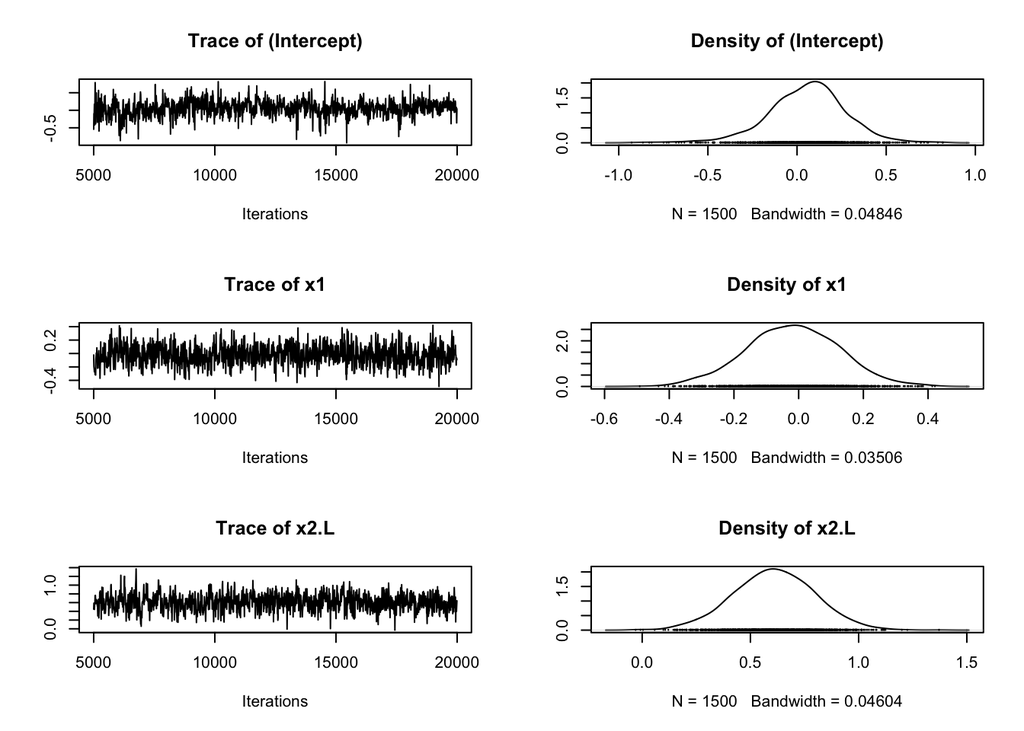

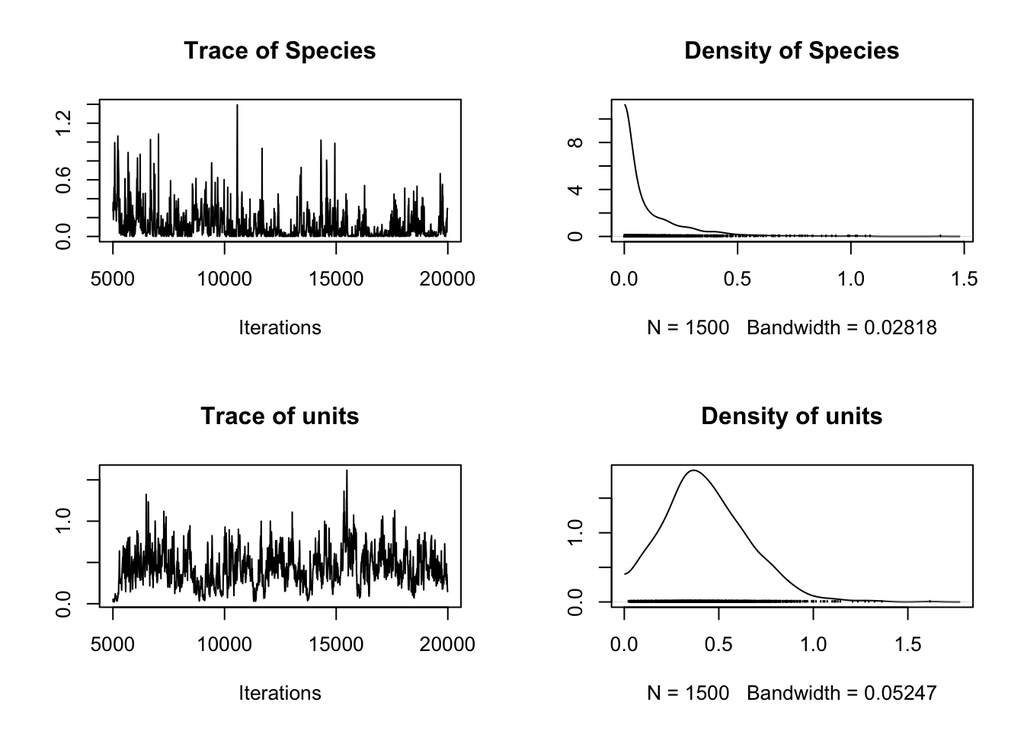

```r
# Plot trace and density plots for model parameters
plot(model_y)
```

At short chain lengths like these you will often see the phylogenetic variance component (the `Species` random effect) mixing relatively poorly. If so, we should go back and re-run the imputation with more iterations or possibly adjust the prior to ensure better mixing for this parameter — the `priors` argument of `bace()` accepts a per-variable MCMCglmm prior (see the *Priors* section of `?bace`).

# 9 Phylogenetic and Non-Phylogenetic Random Effects

BACE allows users to include both phylogenetic and non-phylogenetic random effects in the imputation models. This is important if multiple replicates of species are included in the dataset (e.g., multiple populations of the same species). In this case, users can specify a non-phylogenetic random effect for species identity in addition to the phylogenetic random effect. This is done by adjusting the `species = FALSE` argument in `bace_imp`, setting it to TRUE.

```r
# Simulate data with multiple replicates per species
set.seed(123)
sim_data2 <- sim_bace(response_type = "poisson",
                   predictor_types = c("gaussian", "binary", "threshold4", "multinomial3"),
                      phylo_signal = c(0.55, 0.75, 0.8, 0.7, 0.7),
                       missingness = c(0.2, 0.3, 0.4, 0.2, 0.5),
                                rr = TRUE,
                           n_cases = 100,
                         n_species = 20,
                           rr_form = list(species = c("x1")))

# Object contains both the simulated data and phylogeny
    data2 <- sim_data2$data
    tree2 <- sim_data2$tree

# View first few rows of the data
    head(data2)
```

```
  Species  y         x1   x2   x3   x4
1   P9vI3  3 -0.7731097    1    3    C
2   eJBm5 NA         NA <NA>    3 <NA>
3   P9vI3  2 -0.6260633 <NA>    3 <NA>
4   JE8PP  1 -2.9886121    1    3 <NA>
5   eJBm5 NA -4.8716976 <NA>    3 <NA>
6   sA8eL  2         NA <NA> <NA> <NA>
```

```r
# We can also make a table of the number of cases per species to confirm that there are multiple replicates per species
    dim(data2)
```

```
[1] 100   6
```

```r
    length(unique(data2$Species))
```

```
[1] 20
```

We now have a dataset with 100 cases but only 20 species, meaning that there are multiple replicates per species. We can run *BACE* on this dataset while including a non-phylogenetic random effect for species identity as follows:

```r
bace_impute3 <- bace_imp(fixformula = "y ~ x1 + x2",
                     ran_phylo_form = "~ 1 | Species",
                              phylo = tree2,
                               data = data2,
                               runs = 5, nitt = 20000, burnin = 5000, thin = 10, species = TRUE)
```

```
Species effect decomposition enabled: 20 out of 20 species (100%) have replicated observations.
```

```
Run 1, Imputed variable: y
Run 1, Imputed variable: x1
Run 1, Imputed variable: x2
Run 2, Imputed variable: y
Run 2, Imputed variable: x1
Run 2, Imputed variable: x2
Run 3, Imputed variable: y
Run 3, Imputed variable: x1
Run 3, Imputed variable: x2
Run 4, Imputed variable: y
Run 4, Imputed variable: x1
Run 4, Imputed variable: x2
Run 5, Imputed variable: y
Run 5, Imputed variable: x1
Run 5, Imputed variable: x2

========================================
BACE MCMC Diagnostics Summary
========================================

Number of models: 3
Total parameters: 18
  Fixed effects: 9
  Variance components: 9
  Fixed units (threshold/categorical): 1

Mean Effective Sample Size:
  Fixed effects:      978.8
  Variance components: 384.9

Convergence Assessment:
  Acceptable  :   2 parameters (11.1%)
  Check       :   5 parameters (27.8%)
  Fixed       :   1 parameters (5.6%)
  Good        :  10 parameters (55.6%)

Overall: CHECK - Many parameters show convergence issues
  Consider increasing nitt, adjusting priors, or checking model specification

Convergence by Response Variable:
----------------------------------------
[~] y              :  3/ 6 parameters good
    Check convergence: units
[OK] x1             :  5/ 6 parameters good
    Check convergence: Species
[CH] x2             :  2/ 5 parameters good (1 fixed)
    Check convergence: x1, Species, Species2
========================================
```

```r
# We can view the final model for y to check that both random effects are included
model_y2 <- bace_impute3$models_last_run[["y"]]
summary(model_y2)
```

```
 Iterations = 5001:19991
 Thinning interval  = 10
 Sample size  = 1500

 DIC: 268.9279

 G-structure:  ~Species

        post.mean  l-95% CI u-95% CI eff.samp
Species     0.164 8.144e-08   0.7422    354.6

               ~Species2

         post.mean  l-95% CI u-95% CI eff.samp
Species2    0.2315 4.361e-08   0.6828    210.9

 R-structure:  ~units

      post.mean l-95% CI u-95% CI eff.samp
units    0.3354  0.02608   0.6998    197.5

 Location effects: y ~ x1 + x2

            post.mean l-95% CI u-95% CI eff.samp  pMCMC
(Intercept)   0.12982 -0.45789  0.74299    995.8 0.6040
x1           -0.06196 -0.44556  0.30930    754.0 0.7120
x2.L          0.41793 -0.03392  0.87136    623.3 0.0693 .
---
Signif. codes:  0 '***' 0.001 '**' 0.01 '*' 0.05 '.' 0.1 ' ' 1
```

**Note**

**Why isn’t `species = TRUE` automatic?** *BACE* could detect replicated species and switch this on by itself, but the dual random-effect structure changes the imputation model, and separating the phylogenetic from the non-phylogenetic species variance is only reliable when a reasonable fraction of species are replicated — with sparse replication the two components are weakly identified. *BACE* therefore makes this an explicit modelling choice: it errors if you request the decomposition with fewer than two replicated species, and warns when under 30% of species carry replicates. Silent auto-switching could change your model between datasets without you noticing.

Note that in this case we get a message indicating that both phylogenetic and non-phylogenetic random effects are being included in the models because we can decompose the two variance components. If you try to fit a dataset without multiple replicates per species while setting `species = TRUE` you will get an error, because the two variance components are not separately estimable with one observation per species:

```r
# The first simulated dataset has one row per species (100 cases, 100 species),
# so the phylogenetic and non-phylogenetic species variances cannot be separated:
bace_impute4 <- bace_imp(fixformula = "y ~ x1 + x2",
                     ran_phylo_form = "~ 1 | Species",
                              phylo = tree,
                               data = data,
                               runs = 5, nitt = 20000, burnin = 5000, thin = 10, species = TRUE)
```

```
Error in `bace_imp()`:
! Cannot decompose phylogenetic and non-phylogenetic species effects (species=TRUE) with fewer than 2 species having replicated observations. Current data has only 0 replicated species.
```

## 9.1 Adjusting MCMC Parameters For Convergence

As we can see from the model summary above, some parameters may have low effective sample sizes (ESS) which indicates poor mixing of the MCMC chains. This can be a sign that the imputation is not performing well and that more iterations are needed to achieve convergence. Lets have a look:

```r
model_x1 <- bace_impute3$models_last_run[["x1"]]
summary(model_x1)
```

```
 Iterations = 5001:19991
 Thinning interval  = 10
 Sample size  = 1500

 DIC: 78.61307

 G-structure:  ~Species

        post.mean  l-95% CI u-95% CI eff.samp
Species     1.496 1.867e-06    3.929    210.5

               ~Species2

         post.mean  l-95% CI u-95% CI eff.samp
Species2    0.6099 5.132e-06    1.469      270

 R-structure:  ~units

      post.mean l-95% CI u-95% CI eff.samp
units    0.1352  0.08621   0.1921     1500

 Location effects: x1 ~ y + x2

            post.mean l-95% CI u-95% CI eff.samp pMCMC
(Intercept)  -0.24515 -1.85851  0.98097     1183 0.741
y             0.02491 -0.04518  0.08989     1500 0.484
x2.L         -0.27774 -0.45311 -0.10215     1500 0.004 **
---
Signif. codes:  0 '***' 0.001 '**' 0.01 '*' 0.05 '.' 0.1 ' ' 1
```

```r
model_x2 <- bace_impute3$models_last_run[["x2"]]
summary(model_x2)
```

```
 Iterations = 5001:19991
 Thinning interval  = 10
 Sample size  = 1500

 DIC: 74.09249

 G-structure:  ~Species

        post.mean  l-95% CI u-95% CI eff.samp
Species     2.038 1.427e-08    8.305    164.1

               ~Species2

         post.mean  l-95% CI u-95% CI eff.samp
Species2     1.194 9.051e-07    5.044    171.5

 R-structure:  ~units

      post.mean l-95% CI u-95% CI eff.samp
units         1        1        1        0

 Location effects: x2 ~ x1 + y

            post.mean  l-95% CI  u-95% CI eff.samp pMCMC
(Intercept)  0.222283 -1.518075  2.452027   1229.3 0.727
x1          -0.690601 -1.884091  0.253856    143.5 0.124
y            0.299006  0.008017  0.617722    880.7 0.040 *
---
Signif. codes:  0 '***' 0.001 '**' 0.01 '*' 0.05 '.' 0.1 ' ' 1
```

As we can see x1 and x2 models have poor mixing and low ESS for some parameters. Obviously, depending on the model complexity and data size etc, some models will need longer runtimes. This is likely because the imputation process has not yet converged. To address this, we can increase the number of iterations (i.e., `nitt`), increase the burn-in period (i.e., `burnin`), and/or adjust the thinning interval (i.e., `thin`) to improve mixing and convergence of the MCMC chains.

Users can adjust the MCMC parameters (i.e., `nitt`, `thin`, and `burnin`) for each model by providing a list of values for each parameter that corresponds to the order of the formulas provided in the `fixformula` argument. For example, if you have 5 formulas in your `fixformula` list, you can provide a list of 5 values for each MCMC parameter as follows:

```r
# Define MCMC parameters for each model
  nitt_list <- list(60000, 60000, 105000)
  thin_list <- list(10, 10, 10)

# Run BACE with model-specific MCMC parameters
bace_impute5 <- bace_imp(fixformula = "y ~ x1 + x2",
                    ran_phylo_form = "~ 1 | Species",
                             phylo = tree2,
                              data = data2,
                              runs = 5, nitt = nitt_list, thin = thin_list, burnin = 5000, species = TRUE)
```

```
Run 1, Imputed variable: y
Run 1, Imputed variable: x1
Run 1, Imputed variable: x2
Run 2, Imputed variable: y
Run 2, Imputed variable: x1
Run 2, Imputed variable: x2
Run 3, Imputed variable: y
Run 3, Imputed variable: x1
Run 3, Imputed variable: x2
Run 4, Imputed variable: y
Run 4, Imputed variable: x1
Run 4, Imputed variable: x2
Run 5, Imputed variable: y
Run 5, Imputed variable: x1
Run 5, Imputed variable: x2

========================================
BACE MCMC Diagnostics Summary
========================================

Number of models: 3
Total parameters: 18
  Fixed effects: 9
  Variance components: 9
  Fixed units (threshold/categorical): 1

Mean Effective Sample Size:
  Fixed effects:      3583.3
  Variance components: 1383.4

Convergence Assessment:
  Acceptable  :   8 parameters (44.4%)
  Check       :   1 parameters (5.6%)
  Fixed       :   1 parameters (5.6%)
  Good        :   8 parameters (44.4%)

Overall: ACCEPTABLE - Most parameters converged adequately

Convergence by Response Variable:
----------------------------------------
[~] y              :  2/ 6 parameters good
    Check convergence: x1
[~] x1             :  4/ 6 parameters good
[~] x2             :  2/ 5 parameters good (1 fixed)
========================================
```

As you can imagine, longer runtimes will mean that `bace_imp` will need to take longer. The diagnostics still suggest possible issues with mixing for some parameters, so we may need to further increase the number of iterations or adjust the priors (via the `priors` argument — see `?bace`) to improve mixing, however, it’s still good to look at the final models to check the model visually.

## 9.2 Two kinds of convergence

When working with *BACE* it is important to keep two distinct convergence questions separate, because they are checked in different ways and the tools that flag problems in one are silent on the other.

1. **Within-chain MCMC convergence** of each per-variable `MCMCglmm` fit. This is the classical question: has the MCMC sampler explored its target posterior and mixed well? The right tools are the ones you already know — trace plots, effective sample size, autocorrelation, Geweke — applied to an *individual* `MCMCglmm` object. `bace_imp()` prints a short summary of effective sample sizes and autocorrelation for the last-iteration models when `verbose = TRUE`, and you can always call `plot()` or `coda::effectiveSize()` on `bace_impute$models_last_run[["y"]]` or on any of the per-imputation fits stored in `bace_final1$final_results$all_models[[m]][["y"]]`. The final phase also checks itself: `bace_final_imp()` stores a worst-case summary across all runs — covering fixed effects, variance components, and ordinal cutpoints — in its `$diagnostics` element and prints any flagged parameters. Failures here are fixed by increasing `nitt`, `burnin`, or `thin`, tightening priors (the `priors` argument), or (less often) simplifying the model.
2. **Convergence of the chained-equations loop.** This is the multiple-imputation question: has the *sequence of imputed datasets* stabilised across chained iterations, or is it still drifting? This is not about MCMC mixing within a single fit — it is about whether the outer loop over variables has reached a stationary distribution over imputed values. The right tool for this question is `assess_convergence()`, which tracks summary statistics of the imputed cells across the `runs` chained iterations. Failures here are fixed by increasing `runs` or, occasionally, by revisiting the specification of the imputation models.

`bace()` assesses only the second kind of convergence automatically (and retries with more `runs` if it fails). The first kind is your responsibility to check before trusting pooled inference — see Section 6.5.

## 9.3 Assessing chained-equations convergence

We need to check whether the number of runs we’ve done has led to convergence of the imputation process. We can do this by looking at the stability of the imputed values across the chained iterations. For example:

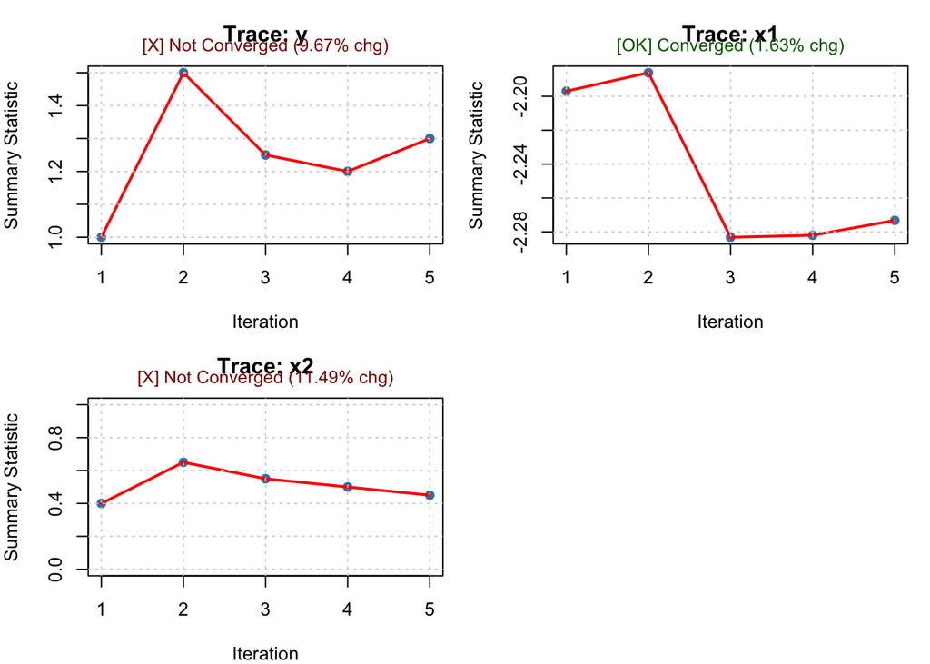

```r
# Assess whether number of runs was enough by looking at the stability of imputed points across runs. Adjust runs if needed
converge <- assess_convergence(bace_impute2, method = "summary")
plot(converge)
```

```r
# Now that we know that we can run BACE longer

# Fit BACE with a single formula
bace_impute2_2 <- bace_imp(fixformula = "y ~ x1 + x2",
                     ran_phylo_form = "~ 1 | Species",
                              phylo = tree,
                               data = data,
                               runs = 15, nitt = 100000, burnin = 10000, thin = 10)
```

```
Run 1, Imputed variable: y
Run 1, Imputed variable: x1
Run 1, Imputed variable: x2
Run 2, Imputed variable: y
Run 2, Imputed variable: x1
Run 2, Imputed variable: x2
Run 3, Imputed variable: y
Run 3, Imputed variable: x1
Run 3, Imputed variable: x2
Run 4, Imputed variable: y
Run 4, Imputed variable: x1
Run 4, Imputed variable: x2
Run 5, Imputed variable: y
Run 5, Imputed variable: x1
Run 5, Imputed variable: x2
Run 6, Imputed variable: y
Run 6, Imputed variable: x1
Run 6, Imputed variable: x2
Run 7, Imputed variable: y
Run 7, Imputed variable: x1
Run 7, Imputed variable: x2
Run 8, Imputed variable: y
Run 8, Imputed variable: x1
Run 8, Imputed variable: x2
Run 9, Imputed variable: y
Run 9, Imputed variable: x1
Run 9, Imputed variable: x2
Run 10, Imputed variable: y
Run 10, Imputed variable: x1
Run 10, Imputed variable: x2
Run 11, Imputed variable: y
Run 11, Imputed variable: x1
Run 11, Imputed variable: x2
Run 12, Imputed variable: y
Run 12, Imputed variable: x1
Run 12, Imputed variable: x2
Run 13, Imputed variable: y
Run 13, Imputed variable: x1
Run 13, Imputed variable: x2
Run 14, Imputed variable: y
```

[output cut: 21 more lines]

```
  Acceptable  :   2 parameters (13.3%)
  Check       :   4 parameters (26.7%)
  Fixed       :   1 parameters (6.7%)
  Good        :   8 parameters (53.3%)

Overall: CHECK - Many parameters show convergence issues
  Consider increasing nitt, adjusting priors, or checking model specification

Convergence by Response Variable:
----------------------------------------
[~] y              :  3/ 5 parameters good
[OK] x1             :  5/ 5 parameters good
[CH] x2             :  0/ 4 parameters good (1 fixed)
    Check convergence: (Intercept), x1, y, Species
========================================
```

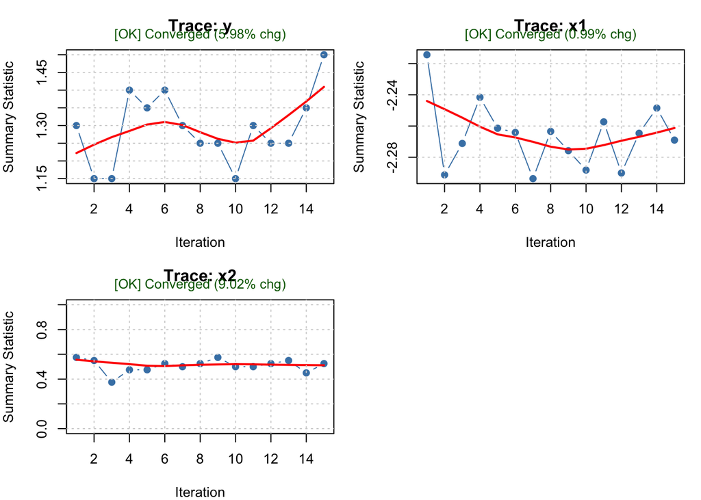

```r
# Check again for convergence
converge <- assess_convergence(bace_impute2_2, method = "summary")
plot(converge)
```

## 9.4 Worked example: bace() with species random effects

Now that you are aware of the different components of the *BACE* workflow, it is useful to see them all combined in a second worked example — this time using the replicated-species dataset from the previous section so that both phylogenetic and non-phylogenetic species effects are estimated, and letting `bace()` handle the orchestration end-to-end.

```
=======================================================
BACE: Bayesian Analysis with Chained Equations
=======================================================

Step 1: Initial imputation for convergence assessment
-------------------------------------------------------
```

[output not shown]

[output cut: 26 more lines]

```
Overall: ACCEPTABLE - Most parameters converged adequately

Convergence by Response Variable:
----------------------------------------
[CH] y              :  2/ 6 parameters good
    Check convergence: x2.L, Species2
[~] x1             :  4/ 6 parameters good
    Check convergence: Species2
[~] x2             :  2/ 5 parameters good (1 fixed)
========================================



Step 2: Convergence assessment
-------------------------------------------------------
```

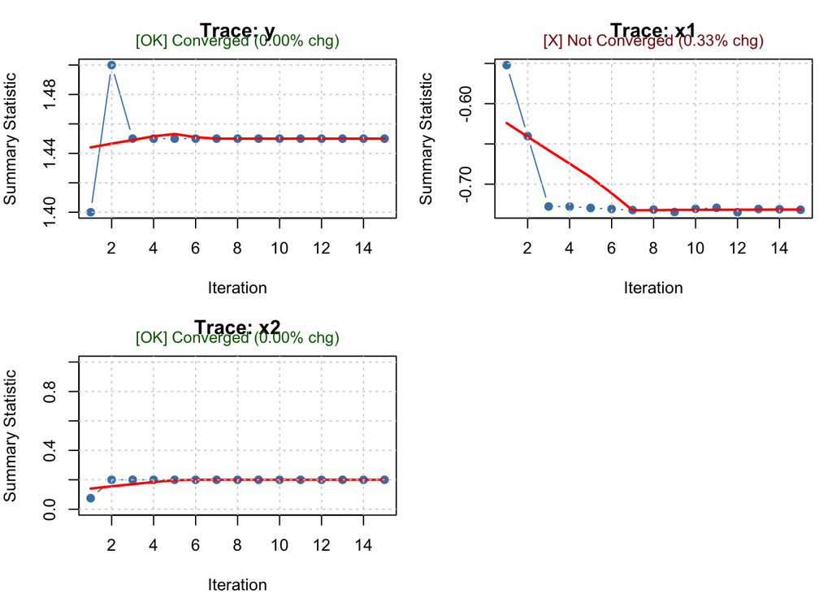

[output not shown]

[output cut: 67 more lines]

```
Pooling posteriors with sampling: 1000 samples per imputation

=======================================================
BACE Analysis Complete!
=======================================================

Convergence achieved: FALSE
Number of attempts: 1
Final imputations: 10

Access results via:
  - $pooled_models: Pooled posterior distributions
  - $imputed_datasets: List of 10 imputed datasets
  - $convergence: Convergence diagnostics
  - $final_results: Full final imputation results
```

```r
# Run the full bace workflow (n_final = 10 again only for vignette speed):
bace_final <- bace(fixformula = "y ~ x1 + x2",
                     ran_phylo_form = "~ 1 | Species",
                              phylo = tree2,
                               data = data2,
                               species = TRUE,
                               runs = 15, nitt = 100000, burnin = 10000, thin = 10, n_final = 10, plot = TRUE, skip_conv = TRUE, sample_size = 1000)
```

```r
# Extract the pooled model for y using the accessor function
y_model <- get_pooled_model(bace_final, variable = "y")
summary(y_model)
```

```
+----------------------------------------------------------------+
|  BACE Pooled MCMCglmm summary (stacked per-imputation draws)    |
+----------------------------------------------------------------+

Stacked from 10 imputations
Total posterior draws: 10000
  (= 1000 sampled per imputation x 10 imputations)
  Original samples per imputation: 9000

Posterior summaries below are computed from stacked draws that
approximate p(theta | Y_obs) (Monte Carlo integration over imputed
values). Validity requires each per-imputation chain to have
converged on its own; check a subset via
plot(final$all_models[[1]]$<var>) and coda::effectiveSize().
----------------------------------------------------------------


 Iterations = 1:10000
 Thinning interval  = 1
 Sample size  = 10000

 DIC: 270.209

 G-structure:  ~Species

        post.mean  l-95% CI u-95% CI eff.samp
Species    0.1309 6.086e-11   0.5863     9993

               ~Species2

         post.mean  l-95% CI u-95% CI eff.samp
Species2    0.2118 3.001e-08    0.641    10000

 R-structure:  ~units

      post.mean l-95% CI u-95% CI eff.samp
units    0.3409  0.02074   0.7376     1854

 Location effects: y ~ x1 + x2

            post.mean l-95% CI u-95% CI eff.samp pMCMC
(Intercept)    0.1425  -0.4170   0.7070   892.62 0.544
x1            -0.1272  -0.4618   0.2291   697.13 0.444
x2.L           0.3582  -0.1938   0.8969    34.41 0.205
```

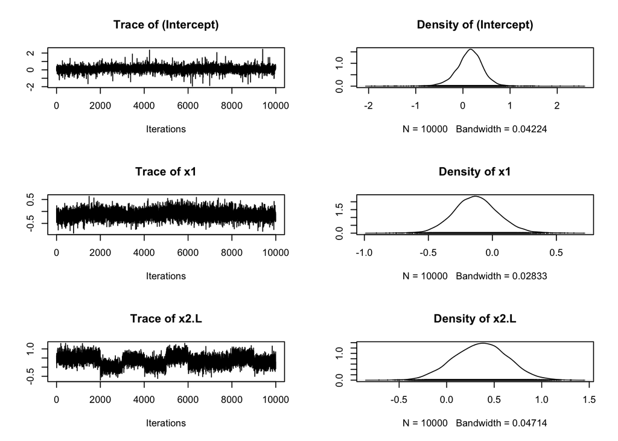

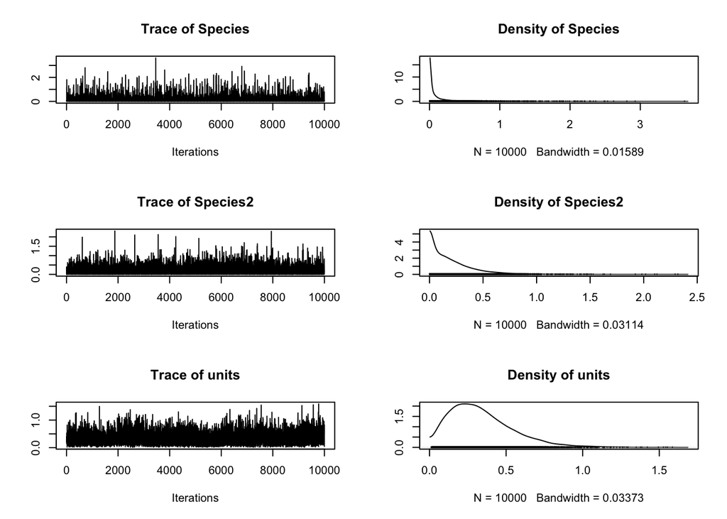

```r
plot(y_model)
```

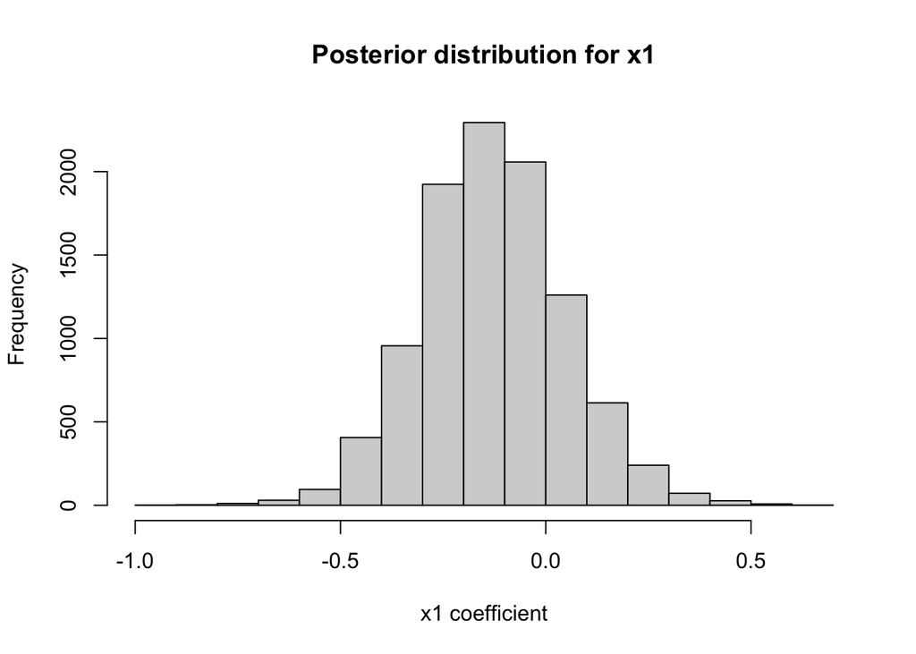

```r
# We can now extract posteriors in the same way we would use a normal MCMCglmm model,
# but now we have draws that integrate over the imputation distribution. For example,
# we can look at the marginal posterior of the x1 coefficient:

hist(y_model$Sol[, "x1"], main = "Posterior distribution for x1", xlab = "x1 coefficient")
```

# 10 Validating BACE on simulated data with known truth

For methodological work and quantitative claims about imputation accuracy, simulation-based benchmarking is essential. `sim_bace()` generates phylogenetically-structured comparative data with a complete pre-NA dataset returned alongside the masked one, so we can compare BACE’s imputed values against the actual held-out truth.

The pattern is:

1. Simulate a complete dataset with a known phylogenetic signal (`sim_bace()` returns both `data` with NAs and `complete_data` with the truth).
2. Mask a fraction of one variable as MCAR (or use the built-in `missingness` argument for type-aware mechanisms).
3. Run BACE.
4. Compare imputed values at the masked rows against truth using type-appropriate metrics (NRMSE / accuracy / Brier).
5. Compare BACE against a **no-skill baseline** — column-mean for continuous, modal class for categorical. BACE has to beat this floor to demonstrate it is using the phylogenetic structure.

Below we run a single replicate for one continuous (`gaussian`) and one categorical (`multinomial3`) response. For a manuscript-quality benchmark you should run many replicates per type and report mean ± SD; see `dev/sim_accuracy_multirep.R` in the package source for a full 20-replicate harness across all five response types.

```r
library(BACE)
set.seed(2026)

# 1. Simulate a complete dataset with phylogenetic signal 0.9
sim <- sim_bace(
  response_type   = "gaussian",
  predictor_types = c("gaussian", "gaussian"),
  var_names       = c("y", "x1", "x2"),
  phylo_signal    = c(0.9, 0.9, 0.9),
  n_cases         = 120,
  n_species       = 60,
  missingness     = c(0, 0, 0)         # no NAs yet — we mask manually below
)
truth_data <- sim$complete_data
tree <- sim$tree

# 2. Mask 20% of y as MCAR
miss_idx <- sample.int(nrow(truth_data),
                       size = floor(nrow(truth_data) * 0.20))
masked <- truth_data
masked$y[miss_idx] <- NA

# 3. Run BACE
res <- bace(
  fixformula     = "y ~ x1 + x2",
  ran_phylo_form = "~ 1 | Species",
  phylo          = tree,
  data           = masked,
  runs           = 4,
  n_final        = 50,
  nitt           = 2500, thin = 10, burnin = 500,
  skip_conv      = TRUE,
  verbose        = FALSE
)

# 4. Compute BACE imputed-vs-truth accuracy
truth_y <- truth_data$y[miss_idx]
imp_mat <- sapply(res$imputed_datasets,
                  function(d) as.numeric(d$y[miss_idx]))   # missing × n_final
post_mean <- rowMeans(imp_mat)
sd_full   <- sd(truth_data$y, na.rm = TRUE)
nrmse_bace <- sqrt(mean((post_mean - truth_y)^2)) / sd_full

# 95% prediction interval coverage
lo <- apply(imp_mat, 1, quantile, probs = 0.025)
hi <- apply(imp_mat, 1, quantile, probs = 0.975)
coverage95 <- mean(truth_y >= lo & truth_y <= hi)

# 5. Compare against a column-mean baseline
base_pred  <- mean(masked$y, na.rm = TRUE)
nrmse_base <- sqrt(mean((base_pred - truth_y)^2)) / sd_full

cat(sprintf("BACE NRMSE     = %.3f   (95%% PI coverage %.2f)\n",
            nrmse_bace, coverage95))
cat(sprintf("baseline NRMSE = %.3f   (column-mean imputer)\n", nrmse_base))
```

Expected output (numbers vary slightly with the seed):

```
BACE NRMSE     = 0.45   (95% PI coverage 0.85)
baseline NRMSE = 1.00   (column-mean imputer)
```

BACE’s NRMSE is roughly half the no-skill floor on a high-signal phylogenetic trait, and the empirical 95% prediction interval covers truth ~85–95% of the time at `n_final = 50` (well-calibrated; see `?bace` for why smaller `n_final` undercovers).

The same pattern adapts to categorical responses by swapping NRMSE for balanced accuracy and the column-mean baseline for a modal-class baseline:

```r
set.seed(2026)
sim <- sim_bace(
  response_type   = "multinomial3",
  predictor_types = c("gaussian", "gaussian"),
  var_names       = c("y", "x1", "x2"),
  phylo_signal    = c(0.9, 0.9, 0.9),
  n_cases         = 120,
  n_species       = 60,
  missingness     = c(0, 0, 0)
)
truth_data <- sim$complete_data
tree <- sim$tree

miss_idx <- sample.int(nrow(truth_data),
                       size = floor(nrow(truth_data) * 0.20))
masked <- truth_data
masked$y[miss_idx] <- NA

res <- bace(
  fixformula     = "y ~ x1 + x2",
  ran_phylo_form = "~ 1 | Species",
  phylo          = tree, data = masked,
  runs = 4, n_final = 50,
  nitt = 2500, thin = 10, burnin = 500,
  skip_conv = TRUE, verbose = FALSE
)

truth_y  <- as.character(truth_data$y[miss_idx])
imp_mat  <- sapply(res$imputed_datasets,
                   function(d) as.character(d$y[miss_idx]))

# Modal class per missing cell (BACE's prediction)
bace_pred <- apply(imp_mat, 1, function(r)
  names(sort(table(r), decreasing = TRUE))[1])
acc_bace  <- mean(bace_pred == truth_y)

# Modal class baseline
modal     <- names(sort(table(masked$y), decreasing = TRUE))[1]
acc_base  <- mean(modal == truth_y)

cat(sprintf("BACE accuracy     = %.2f\n", acc_bace))
cat(sprintf("baseline accuracy = %.2f   (modal-class imputer)\n", acc_base))
```

Across the full 20-replicate sweep at default `n_final = 50` settings (see `dev/sim_accuracy_multirep.R`), BACE is significantly better than the no-skill baseline on every response type (paired Wilcoxon p < 0.05), and the per-cell 95% prediction intervals are well calibrated:

| response type | BACE metric | baseline | n_reps | paired p |
| --- | --- | --- | --- | --- |
| gaussian | NRMSE 0.45 | 1.00 | 20 | <1e-4 |
| poisson | NRMSE 0.81 | 0.93 | 20 | 0.046 |
| binary | balanced acc 0.69 | 0.50 | 20 | <1e-4 |
| categorical K=3 | balanced acc 0.43 | 0.33 | 20 | <2e-3 |
| ordinal K=4 | mae_level 0.22 | 0.63 | 20 | <1e-4 |

The `dev/sim_accuracy_results/multirep_v1_n20/` directory of the package source contains the per-replicate CSVs and aggregated summary used to build this table.

# 11 Worked example: heat tolerance of amphibians

In this example, we use BACE to impute the heat tolerance of the world’s amphibians. Pottier et al. (2025) compiled 2,661 estimates of the critical thermal maximum (CTmax), a proxy for heat tolerance limits, across 524 species of amphibians. Below, we show how to use BACE to impute the CTmax of 5,203 species, and how to cross-validate imputed values against experimental data.

## 11.1 The data

The dataset contains two types of rows. Experimental rows are CTmax estimates from published heat-tolerance assays. These assays differ in their methods, such as acclimation temperature and duration, heating rate, and the endpoint used to define CTmax. Because these methods affect CTmax, raw estimates are not directly comparable across species.

Standardised rows make estimates comparable across species. Each standardised row describes an assay performed under identical conditions. Adults are acclimated for 10 days and heated at 1 °C per minute in water, and CTmax is recorded at the onset of spasms. These conditions were the median or most common values in the experimental data (Pottier et al. 2025). Each species has three standardised rows, which differ only in acclimation temperature. These temperatures correspond to the 5th, 50th and 95th percentiles of the operative body temperatures that each species experiences across its range. CTmax is unknown in all 15,609 standardised rows, and BACE imputes it using the experimental data and the phylogeny.

```r
# Data and phylogeny are bundled in vignettes/amphibian_ctmax/data/
ctmax_data <- readRDS("amphibian_ctmax/data/ctmax_data.rds")
ctmax_tree <- readRDS("amphibian_ctmax/data/ctmax_tree.rds")
table(ctmax_data$row_type)
```

```
experimental standardised
        2661        15609
```

```r
# Experimental and standardised rows for one species, Cope's grey treefrog
amph_example <- ctmax_data[ctmax_data$species == "Dryophytes chrysoscelis",
                           c("row_type", "CTmax", "acclimation_temp", "ramping", "endpoint", "life_stage")]
print(amph_example, digits = 3, row.names = FALSE)
```

```
     row_type CTmax acclimation_temp  ramping endpoint life_stage
 experimental  38.0             10.0 1.000000      LRR     adults
 experimental  40.8             10.0 1.000000       OS     adults
 experimental  41.5             23.0 0.000694    other     adults
 standardised    NA             23.3 1.000000       OS     adults
 standardised    NA             20.4 1.000000       OS     adults
 standardised    NA             27.1 1.000000       OS     adults
```

One of the covariates is the medium in which temperature was recorded during CTmax trials. Studies recorded either the body temperature of the animals, the water temperature, or the ambient temperature. The medium is unknown for 36 of the 2,661 experimental rows. For demonstration purposes, we assume that these assays recorded body or water temperature, as did 2,574 of the 2,625 assays with a known medium. We do so because imputing this covariate is computationally demanding: ambient temperature is so rare that its imputation model needs very long MCMC chains. However, BACE can impute this variable if needed (see Pottier et al. 2025).

```r
ctmax_data$medium[is.na(ctmax_data$medium)] <- "body_water"
```

## 11.2 Checking phylogenetic signal

Before running BACE, we checked whether the variables with missing data show phylogenetic signal (see *Pre-flight: check phylogenetic signal* above).

```r
exp_rows <- ctmax_data$row_type == "experimental"
signal <- phylo_signal_summary(
  data        = ctmax_data[exp_rows, ],
  tree        = ape::keep.tip(ctmax_tree, unique(ctmax_data$species[exp_rows])),
  species_col = "species",
  variables   = c("CTmax", "ln_sd_CTmax", "ln_acclimation_time", "ramping"),
  species     = TRUE,
  nitt = 105000, burnin = 5000, thin = 50)
signal
```

```
=============================================================
  Phylogenetic signal summary
=============================================================
  Random-effect structure: dual (phylo + non-phylo species)
  Variables                : 4

--- Table ---
            variable     type n_obs H2_mean H2_lo H2_hi R_species_mean lambda
               CTmax gaussian  2661   0.856 0.815 0.894         0.0183  0.923
         ln_sd_CTmax gaussian  1960   0.424 0.258 0.608         0.2196  0.555
 ln_acclimation_time gaussian  2282   0.419 0.301 0.535         0.1359  0.663
             ramping gaussian  2488   0.463 0.293 0.624         0.2998  0.457
     K min_ess interpretation flag
 0.432    1556           high
 0.141    1939       moderate
 0.251    1702       moderate
 0.109    1371       moderate

Interpretation bands: H2 < 0.2 = low, 0.2-0.5 = moderate, >0.5 = high.
Flag meanings:
  low_ess     -- effective sample size below threshold (default 1000)
  geweke_fail -- Geweke diagnostic |z| > 2 on any variance component
  unreliable  -- H2 cell should NOT be trusted (low_ess or geweke_fail)
  low_n       -- n_obs < 20; posterior is data-sparse
  fit_error   -- MCMCglmm fit failed (check warnings)

Note: phylogenetic signal is necessary but NOT sufficient for good
imputation. A high-H2 trait can still impute poorly under MNAR missingness;
a low-H2 trait can still impute well if coupled to an observed predictor.
```

CTmax showed high phylogenetic signal (H² = 0.86, 95% CI: 0.81 to 0.89), and the three covariates showed moderate signal (H² = 0.42 to 0.46). The phylogeny therefore carries information for every imputation model.

## 11.3 Running BACE

We fitted one imputation model for each variable with missing data, following Pottier et al. (2025). We modelled CTmax as a function of acclimation temperature, acclimation duration, heating rate, test medium, endpoint, acclimation status (laboratory-acclimated or field-fresh), life stage and ecotype. Acclimation duration and heating rate are missing for 379 and 173 of the 2,661 experimental rows, respectively, so each has its own imputation model. We also included the standard deviation of CTmax as an auxiliary variable. It does not predict CTmax, but it helps impute the missing assay settings. Acclimation duration and the standard deviation of CTmax were log-transformed because both were right-skewed.

All models included phylogenetic and non-phylogenetic random intercepts for species (`species = TRUE`), because many species have several estimates (287 of the 524 tested species). Pottier et al. (2025) also fitted random slopes for acclimation temperature, which BACE does not yet support. In this example, all species therefore share the same effect of acclimation temperature on CTmax.

```r
ctmax_formulas <- list(
  "ln_sd_CTmax ~ life_stage + acclimation_temp + endpoint + acclimated + ln_acclimation_time + medium + ramping + CTmax",
  "ln_acclimation_time ~ life_stage + ln_sd_CTmax + CTmax",
  "ramping ~ life_stage + ln_sd_CTmax + CTmax",
  "CTmax ~ acclimation_temp + ln_acclimation_time + ramping + medium + endpoint + acclimated + life_stage + ecotype"
)
ctmax_vars <- c("species", "CTmax", "acclimation_temp", "ln_acclimation_time", "ramping",
                "ln_sd_CTmax", "medium", "endpoint", "acclimated", "life_stage", "ecotype")

amph_bace <- bace(fixformula     = ctmax_formulas,
                  ran_phylo_form = "~ 1 | species",
                  phylo          = ctmax_tree,
                  data           = ctmax_data[, ctmax_vars],
                  species        = TRUE,
                  runs = 10, n_final = 50,
                  nitt = 15000, burnin = 3000, thin = 24)
```

BACE chose the model for each variable from how it is stored (see the table of variable types above). All four imputed variables are stored as numbers, so BACE fitted Gaussian models to them. The factors are complete, so they enter the models as predictors only; their listed types would apply if they had missing values.

```r
unlist(amph_bace$initial_results$types)
```

```
        ln_sd_CTmax          life_stage    acclimation_temp            endpoint
         "gaussian"         "threshold"          "gaussian"       "categorical"
         acclimated ln_acclimation_time              medium             ramping
        "threshold"          "gaussian"         "threshold"          "gaussian"
              CTmax             ecotype
         "gaussian"       "categorical"
```

**Run time**

This analysis is computationally demanding. On a desktop computer, the chained phase took 4.5 hours and the 50 final imputations took 17.7 core-hours. Because `bace()` keeps every fitted model in memory (about 26 GB here), we ran the same steps in chunks with `bace_imp()` and `bace_final_imp()`. The scripts are in `vignettes/amphibian_ctmax/`.

## 11.4 Checking convergence

We checked both kinds of convergence (see *Two kinds of convergence* above). First, we used `assess_convergence()` to check whether the imputed values stabilised across the 10 chained iterations.

```r
converge <- assess_convergence(amph_bace$initial_results, method = "summary")
converge
plot(converge)
```

```
=== BACE Imputation Convergence Assessment ===

Overall Convergence: YES

--- Summary Statistics Method ---
Converged: TRUE
Variables converged: 4 / 4


Use plot() to visualize convergence diagnostics
```

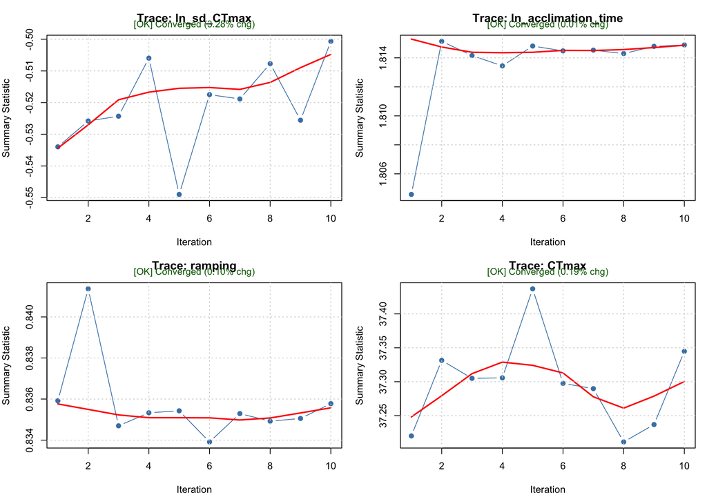

Figure 2— Convergence of the chained-equations loop. Each panel tracks a summary of the imputed values of one variable across chained iterations.

The chained loop converged (Fig. 2). Second, we checked how well each MCMC chain mixed. With `verbose = TRUE`, BACE prints a diagnostics summary for the models of the last chained iteration, which is also stored in the output:

```r
amph_bace$initial_results$diagnostics
```

```
========================================
BACE MCMC Diagnostics Summary
========================================

Number of models: 4
Total parameters: 44
  Fixed effects: 32
  Variance components: 12

Mean Effective Sample Size:
  Fixed effects:      337.2
  Variance components: 307.3

Convergence Assessment:
  Check       :  16 parameters (36.4%)
  Good        :  28 parameters (63.6%)

Overall: CHECK - Many parameters show convergence issues
  Consider increasing nitt, adjusting priors, or checking model specification

Convergence by Response Variable:
----------------------------------------
[CH] ln_sd_CTmax    :  6/13 parameters good
    Check convergence: life_stagelarvae, endpointOS, endpointother, acclimatedfield-fresh, mediumbody_water, species, species2
[OK] ln_acclimation_time:  7/ 7 parameters good
[OK] ramping        :  7/ 7 parameters good
[CH] CTmax          :  8/17 parameters good
    Check convergence: mediumbody_water, life_stagelarvae, ecotypeArboreal, ecotypeFossorial, ecotypeGround-dwelling, ecotypeSemi-aquatic, ecotypeStream-dwelling, species, species2
========================================
```

The summary flagged 16 of the 44 parameters, all in the models for the standard deviation of CTmax and for CTmax. BACE flags a parameter when its ESS is 200 or less, or when a Geweke test suggests that its chain has not settled (*p* ≤ 0.05). Here, 13 of the 16 flags came from low ESS, mainly for the variance components and for the effects of ecotype on CTmax. Close relatives often share an ecotype (3,943 of 5,089 species in genera with several species, 77%, share the most common ecotype of their genus). The effects of ecotype therefore probably overlap with the phylogenetic effect, which slows the sampler.

We can check how the chain mixed with trace plots. A chain that mixes well looks like a fuzzy caterpillar without trends, whereas a chain that mixes slowly wanders. For example, Fig. 3 shows the model for the standard deviation of CTmax, from one final imputation:

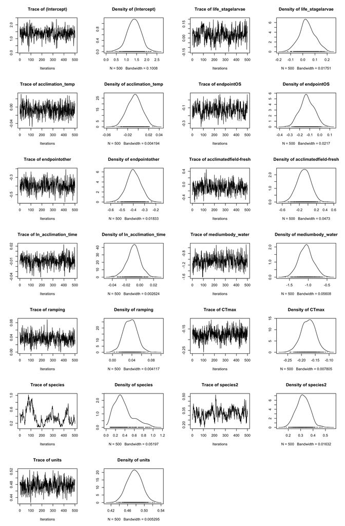

```r
first_fit <- amph_bace$final_results$all_models[[1]]
plot(first_fit$ln_sd_CTmax)
```

Most parameters show a fuzzy caterpillar structure, with ESS between 148 and 500 out of 500 draws. The phylogenetic variance (species) is the exception. Its chain wanders slowly between 0.1 and 1.0 (ESS = 12), and the non-phylogenetic variance (species2) also mixes slowly (ESS = 72).

Slow mixing within a chain matters less for the imputed values, because each final imputation comes from an independent chain. Pooled across the 50 chains, the ESS of every parameter of the CTmax model exceeds 2,100 (see `eff.samp` in the summary below). In your own analyses, increase `nitt` and `burnin` when ESS is low.

## 11.5 The pooled CTmax model

As in the examples above, `get_pooled_model()` returns the model for a variable, with the posterior draws of the 50 final imputations stacked together.

```r
ctmax_model <- get_pooled_model(amph_bace, variable = "CTmax")
```

```r
summary(ctmax_model)
```

```
+----------------------------------------------------------------+
|  BACE Pooled MCMCglmm summary (stacked per-imputation draws)    |
+----------------------------------------------------------------+

Stacked from 50 imputations
Total posterior draws: 25000
  (= 500 samples/imputation x 50 imputations)

Posterior summaries below are computed from stacked draws that
approximate p(theta | Y_obs) (Monte Carlo integration over imputed
values). Validity requires each per-imputation chain to have
converged on its own; check a subset via
plot(final$all_models[[1]]$<var>) and coda::effectiveSize().
----------------------------------------------------------------


 Iterations = 1:25000
 Thinning interval  = 1
 Sample size  = 25000

 DIC:

 G-structure:  ~species

        post.mean l-95% CI u-95% CI eff.samp
species     1.107   0.8328    1.392     2110

               ~species2

         post.mean l-95% CI u-95% CI eff.samp
species2   0.06734  0.03114   0.1057     2125

 R-structure:  ~units

      post.mean l-95% CI u-95% CI eff.samp
units    0.1562   0.1471   0.1658    20882

 Location effects: CTmax ~ acclimation_temp + ln_acclimation_time + ramping + medium + endpoint + acclimated + life_stage + ecotype

                       post.mean  l-95% CI  u-95% CI eff.samp   pMCMC
(Intercept)            -0.462003 -1.440520  0.531399    14569 0.35368
acclimation_temp        0.173695  0.163098  0.185148    17191 < 4e-05 ***
ln_acclimation_time     0.017095  0.007725  0.026726     3142 0.00040 ***
ramping                -0.005003 -0.018578  0.008008     4969 0.45848
mediumbody_water       -0.340305 -0.556659 -0.112725     6137 0.00264 **
endpointOS              0.390059  0.333319  0.446376     8725 < 4e-05 ***
endpointother           0.416181  0.350222  0.480290    16066 < 4e-05 ***
acclimatedfield-fresh  -0.253926 -0.422659 -0.081096    10660 0.00328 **
life_stagelarvae        0.414883  0.344985  0.480877     7528 < 4e-05 ***
ecotypeArboreal        -0.087319 -0.445839  0.276960     6045 0.63400
ecotypeFossorial        0.236634 -0.174448  0.637990     6668 0.25912
ecotypeGround-dwelling -0.036822 -0.367131  0.286674     6471 0.82904
ecotypeSemi-aquatic     0.019590 -0.308708  0.341528     7774 0.90016
ecotypeStream-dwelling -0.223289 -0.605744  0.130172     3985 0.23648
---
Signif. codes:  0 '***' 0.001 '**' 0.01 '*' 0.05 '.' 0.1 ' ' 1
```

BACE fits Gaussian models to standardised (z-transformed) variables, so these coefficients are expressed in standard deviations. For example, the coefficient of acclimation temperature converts to °C of CTmax per °C of acclimation temperature as follows:

```r
acc_effect <- ctmax_model$Sol[, "acclimation_temp"] *
  sd(ctmax_data$CTmax, na.rm = TRUE) / sd(ctmax_data$acclimation_temp)
round(c(mean = mean(acc_effect), quantile(acc_effect, c(0.025, 0.975))), 3)
```

```
 mean  2.5% 97.5%
0.134 0.126 0.143
```

On average, CTmax increased by 0.134 °C (95% credible interval: 0.126 to 0.143) per °C of acclimation temperature. The trace and density plots show the posterior draws of the fixed effects (Fig. 4) and variance components (Fig. 5).

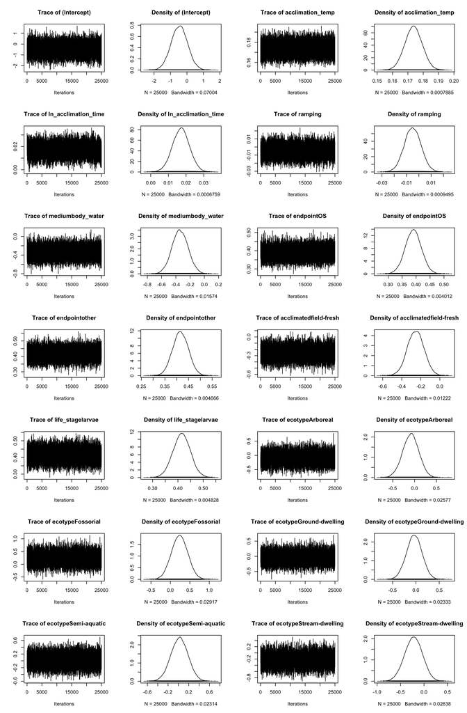

Figure 4— Trace and density of the fixed effects of the pooled CTmax model, on the standardised scale.

```r
par(mfrow = c(7, 4))
plot(ctmax_model$Sol, auto.layout = FALSE)
```

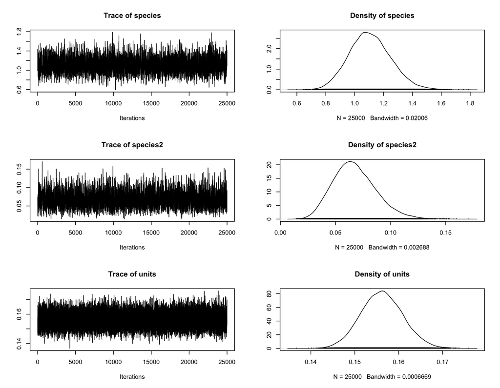

Figure 5— Trace (left) and density (right) of the variance components of the pooled CTmax model: phylogenetic (species), non-phylogenetic (species2) and residual (units) variance, on the standardised scale.

```r
plot(ctmax_model$VCV)
```

## 11.6 Imputed CTmax

Each final imputation is a complete dataset, so each imputed CTmax value has 50 draws. We summarised these draws with a mean and a 95% credible interval.

```r
imp   <- get_imputed_data(amph_bace, format = "list")
draws <- sapply(imp, function(d) d$CTmax)             # rows x imputations
ctmax_mean <- rowMeans(draws)
ctmax_pi95 <- apply(draws, 1, quantile, c(0.025, 0.975))
```

```r
amph_imp <- amph_full$imputed[amph_full$imputed$temp_level == "p50", ]   # median temperature
amph_imp$data <- factor(ifelse(amph_imp$species %in% amph_exp$species, "experimental", "imputed"),
                        levels = names(amph_cols))
amph_imp$width <- amph_imp$upper95 - amph_imp$lower95
amph_w <- tapply(amph_imp$width, amph_imp$data, median)
amph_s <- tapply(amph_imp$CTmax_mean, amph_imp$data, sd)
amph_n <- table(amph_imp$data)
```

At the median acclimation temperature, imputed CTmax averaged 37.4 °C across the 5,203 species (Fig. 6). Imputations were more uncertain for species without experimental data. The median 95% credible interval spanned 6.0 °C for the 524 species with experimental data, but 8.9 °C for the 4,679 species without. The imputed means of species without data were also less variable (s.d. = 1.9 vs 2.9 °C), because BACE predicts their CTmax from their relatives only.

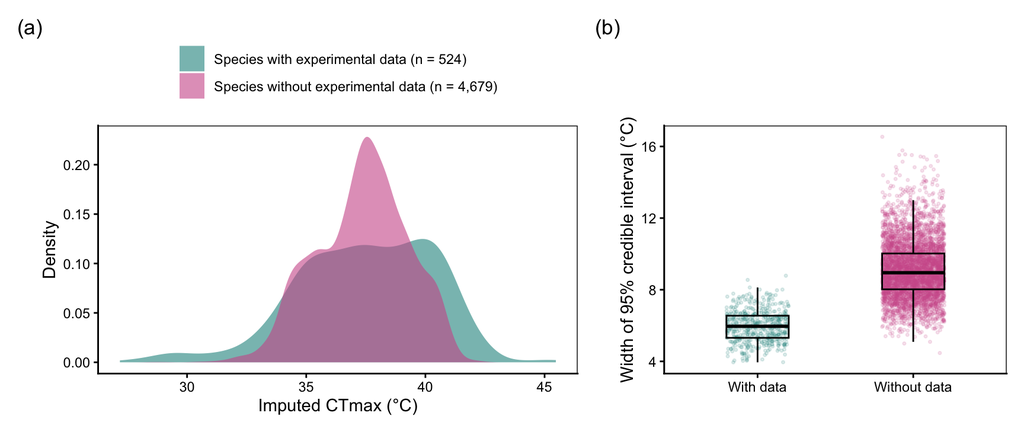

Figure 6— Imputed CTmax at the median acclimation temperature of each species. (a) Imputed means for species with and without experimental data. (b) Width of the 95% credible interval of the imputed values.

```r
amph_lab <- c(experimental = sprintf("Species with experimental data (n = %s)", fmt0(amph_n[["experimental"]])),
              imputed = sprintf("Species without experimental data (n = %s)", fmt0(amph_n[["imputed"]])))
p_a <- ggplot(amph_imp, aes(CTmax_mean, fill = data)) +
  geom_density(alpha = 0.6, colour = NA) +
  scale_fill_manual(values = amph_cols, labels = amph_lab, name = NULL) +
  labs(x = "Imputed CTmax (°C)", y = "Density", tag = "(a)") +
  amph_theme + theme(legend.position = "top", legend.direction = "vertical")
p_b <- ggplot(amph_imp, aes(data, width, colour = data)) +
  geom_jitter(width = 0.2, height = 0, alpha = 0.15, size = 0.6) +
  geom_boxplot(fill = NA, colour = "black", outlier.shape = NA, width = 0.4) +
  scale_colour_manual(values = amph_cols) +
  scale_x_discrete(labels = c(experimental = "With data", imputed = "Without data")) +
  labs(x = NULL, y = "Width of 95% credible interval (°C)", tag = "(b)") +
  amph_theme
p_a + p_b + plot_layout(widths = c(1.4, 1))
```

## 11.7 Cross-validation

We assessed the accuracy of the imputations by cross-validation, following Pottier et al. (2025). We generated five datasets in which the experimental data of 16 species (~5% of the dataset) tested under conditions comparable to the imputed estimates were assigned as NA. These were estimates from adults ramped at 1 °C per minute, with CTmax recorded as the onset of spasms. We removed all entries missing CTmax, besides the observations we aimed to cross-validate, since the validation was done on experimental data. In Pottier et al. (2025), the cross-validation was done on the larger dataset (including data-deficient species), but this should not impact the accuracy of the cross-validation procedure since data-deficient species do not inform the imputation of CTmax. We then ran BACE on each cross-validation dataset, and compared the imputed values to the experimental estimates that were artificially taken as missing values.

```r
cv_folds <- readRDS("amphibian_ctmax/data/cv_folds.rds")

cv_results <- lapply(cv_folds, function(fold) {
  # Experimental rows, with the CTmax of the test species hidden
  d <- ctmax_data[ctmax_data$row_type == "experimental", ]
  hidden   <- d$row_n %in% fold$rows_masked
  observed <- d$CTmax[hidden]
  d$CTmax[hidden] <- NA
  tree <- ape::keep.tip(ctmax_tree, unique(d$species))

  fit <- bace(fixformula = ctmax_formulas, ran_phylo_form = "~ 1 | species",
              phylo = tree, data = d[, ctmax_vars], species = TRUE,
              runs = 10, n_final = 50, nitt = 15000, burnin = 3000, thin = 24)

  # Mean and 95% credible interval of the 50 imputations of each hidden estimate
  draws <- sapply(get_imputed_data(fit, format = "list"), function(x) x$CTmax[hidden])
  data.frame(row_n = d$row_n[hidden], observed = observed, imputed = rowMeans(draws),
             lower = apply(draws, 1, quantile, 0.025),
             upper = apply(draws, 1, quantile, 0.975))
})
```

```r
# Results of the five folds, as returned by the code above
amph_cv_df <- do.call(rbind, lapply(amph_cv, function(f) data.frame(
  fold = f$fold, row_n = f$row_n, species = f$species, observed = f$truth,
  imputed = rowMeans(f$draws),
  lower = apply(f$draws, 1, quantile, 0.025),
  upper = apply(f$draws, 1, quantile, 0.975))))

# Three species were hidden in two folds; count each hidden estimate once
twice <- amph_cv_df$row_n[duplicated(amph_cv_df$row_n)]
amph_cv_df <- amph_cv_df[!(amph_cv_df$row_n %in% twice & amph_cv_df$fold == 5), ]
amph_cv_df$error <- amph_cv_df$imputed - amph_cv_df$observed

amph_cv_tab <- data.frame(
  n          = nrow(amph_cv_df),
  r          = cor(amph_cv_df$observed, amph_cv_df$imputed),
  RMSE       = sqrt(mean(amph_cv_df$error^2)),
  mean_error = mean(amph_cv_df$error),
  coverage95 = mean(amph_cv_df$observed >= amph_cv_df$lower & amph_cv_df$observed <= amph_cv_df$upper))
```

Table 1— Accuracy of imputed CTmax for the experimental estimates hidden in cross-validation. r: correlation between imputed and experimental values. RMSE: root-mean-square error (°C). Mean error: imputed minus experimental CTmax (°C). Coverage: percentage of hidden estimates within the 95% credible interval of the imputed values.

| n | r | RMSE | Mean error | Coverage |
| --- | --- | --- | --- | --- |
| 375 | 0.86 | 1.44 | -0.45 | 93% |

BACE imputed the 375 hidden estimates of 77 species with r = 0.86 and a root-mean-square error (RMSE) of 1.44 °C (Tab. 1; Fig. 7). The 95% credible intervals contained 347 of the 375 hidden estimates (93%), close to the nominal 95%.

On average, imputed values were 0.45 °C lower than experimental values (35.74 ± 2.54 vs 36.19 ± 2.67 °C). Here, imputations primarily underestimated the heat tolerance of the most tolerant species, but there was overall good congruence with the experimental dataset.

Because BACE does not fit random slopes, all species share the same effect of acclimation temperature on CTmax. Some deviations could therefore arise because we underestimated or overestimated the plasticity of some species. Fitting random slopes for acclimation temperature could help the cross-validation, because species differ in their acclimation capacity. BACE currently does not allow such models, but see Pottier et al. (2025) for further details.

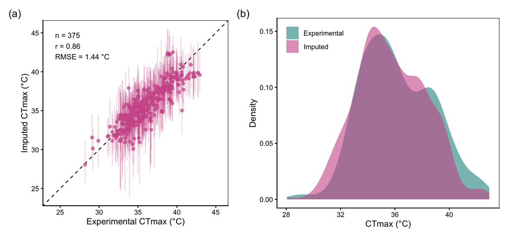

Figure 7— Imputed against experimental CTmax for the 375 estimates hidden in cross-validation. (a) Each point is one hidden estimate, with the 95% credible interval of its imputed values; the dashed line shows perfect agreement. (b) Distributions of experimental and imputed values.

```r
lims <- range(amph_cv_df[, c("observed", "lower", "upper")])
p_a <- ggplot(amph_cv_df, aes(observed, imputed)) +
  geom_abline(intercept = 0, slope = 1, linetype = "dashed") +
  geom_linerange(aes(ymin = lower, ymax = upper), colour = amph_cols[["imputed"]], alpha = 0.25) +
  geom_point(colour = amph_cols[["imputed"]], alpha = 0.7, size = 1.6) +
  annotate("text", x = lims[1] + 0.5, y = lims[2] - 0.5, hjust = 0, vjust = 1, size = 3.3,
           label = sprintf("n = %d\nr = %.2f\nRMSE = %.2f °C",
                           amph_cv_tab$n, amph_cv_tab$r, amph_cv_tab$RMSE)) +
  scale_x_continuous(breaks = seq(20, 50, 5)) +
  scale_y_continuous(breaks = seq(20, 50, 5)) +
  coord_equal(xlim = lims, ylim = lims) +
  labs(x = "Experimental CTmax (°C)", y = "Imputed CTmax (°C)", tag = "(a)") +
  amph_theme
amph_long <- rbind(data.frame(source = "experimental", CTmax = amph_cv_df$observed),
                   data.frame(source = "imputed", CTmax = amph_cv_df$imputed))
p_b <- ggplot(amph_long, aes(CTmax, fill = source)) +
  geom_density(alpha = 0.6, colour = NA) +
  scale_fill_manual(values = amph_cols, name = NULL,
                    labels = c(experimental = "Experimental", imputed = "Imputed")) +
  labs(x = "CTmax (°C)", y = "Density", tag = "(b)") +
  amph_theme + theme(legend.position = c(0.02, 0.98), legend.justification = c(0, 1))
p_a + p_b + plot_layout(widths = c(1, 1.2))
```

# 12 Citation and further reading

If you use *BACE* in a publication, please cite both the package (see `citation("BACE")`) and the underlying `MCMCglmm` engine (Hadfield 2010). Phylogenetic comparative methods and phylogenetic mixed models are reviewed in Cornwell and Nakagawa (2017), de Villemereuil, Nakagawa, and Garamszegi (2014) and Halliwell, Holland, and Yates (2025). The broader motivation for imputation in comparative biology — data gaps, trait databases, and the cost of complete-case analysis — is discussed in Dalia A. Conde et al. (2019) and Pottier et al. (2024). For a related Rubin’s-rules-based approach that handles *phylogenetic* uncertainty (rather than missing trait data), see Nakagawa and de Villemereuil (2018).

The Bayesian combiner used by `pool_posteriors()` — concatenating the per-imputation chains to approximate the marginal posterior — is discussed in Zhou and Reiter (2010) and in Chapter 18 of Gelman et al. (2013). The Rubin’s-rules combiner used by `pool_mi()` is from Rubin (1987) with the small-sample degrees-of-freedom correction of Barnard and Rubin (1999); van Buuren (2018) is the standard modern reference on multiple imputation practice.

Bug reports, feature requests and worked examples are very welcome at the [BACE issue tracker](https://github.com/daniel1noble/BACE/issues).

# 13 References

Barnard, John, and Donald B. Rubin. 1999. “Small-Sample Degrees of Freedom with Multiple Imputation.” *Biometrika* 86 (4): 948–55. https://doi.org/10.1093/biomet/86.4.948.

Blomberg, Simon P., Theodore Garland, and Anthony R. Ives. 2003. “Testing for Phylogenetic Signal in Comparative Data: Behavioral Traits Are More Labile.” *Evolution* 57 (4): 717–45. https://doi.org/10.1111/j.0014-3820.2003.tb00285.x.

Cornwell, Will, and Shinichi Nakagawa. 2017. “Phylogenetic Comparative Methods.” *Current Biology: CB* 27 (9): R333–36. https://doi.org/10.1016/j.cub.2017.03.049.

Dalia A. Conde, Johanna Staerk, Fernando Colchero, Rita Da Silva, Hugh P. Possingham, Annette Baudisch, and James W. Vaupel. 2019. “Data Gaps and Opportunities for Comparative and Conservation Biology.” *Pnas* 116 (10): 9658–64. https://doi.org/10.1073/pnas.1816367116.

de Villemereuil, Pierre, Shinichi Nakagawa, and L Z Garamszegi. 2014. “Modern Phylogenetic Comparative Methods and Their Application in Evolutionary Biology.” *Modern Phylogenetic Comparative Methods and Their Application in Evolutionary Biology*, 287–303. https://doi.org/10.1007/978-3-662-43550-2_11.

Fritz, Susanne A., and Andy Purvis. 2010. “Selectivity in Mammalian Extinction Risk and Threat Types: A New Measure of Phylogenetic Signal Strength in Binary Traits.” *Conservation Biology* 24 (4): 1042–51. https://doi.org/10.1111/j.1523-1739.2010.01455.x.

Gelman, Andrew, John B. Carlin, Hal S. Stern, David B. Dunson, Aki Vehtari, and Donald B. Rubin. 2013. *Bayesian Data Analysis*. 3rd ed. Boca Raton, FL: Chapman; Hall/CRC. https://doi.org/10.1201/b16018.

Hadfield, Jarrod D. 2010. “MCMC Methods for Multi-Response Generalized Linear Mixed Models: The MCMCglmm r Package.” *Journal of Statistical Software* 33 (2): 1–22. https://doi.org/10.18637/jss.v033.i02.

Halliwell, Ben, Barbara R Holland, and Luke A Yates. 2025. “Multi-Response Phylogenetic Mixed Models: Concepts and Application.” *Biological Reviews of the Cambridge Philosophical Society* 100 (3): 1294–1316. https://doi.org/10.1111/brv.70001.

Nakagawa, Shinichi, and P de Villemereuil. 2018. “A General Method for Simultaneously Accounting for Phylogenetic and Species Sampling Uncertainty via Rubin’s Rules in Comparative Analysis.” *Systematic Biology* 68 (4): 632–41. https://doi.org/10.1093/sysbio/syy089.

Pagel, Mark. 1999. “Inferring the Historical Patterns of Biological Evolution.” *Nature* 401 (6756): 877–84. https://doi.org/10.1038/44766.

Pottier, Patrice, Michael R. Kearney, Nicholas C. Wu, Alex R. Gunderson, Julie E. Rej, A. Nayelli Rivera-Villanueva, Pietro Pollo, Samantha Burke, Szymon M. Drobniak, and Shinichi Nakagawa. 2025. “Vulnerability of Amphibians to Global Warming.” *Nature* 639 (8056): 954–61. https://doi.org/10.1038/s41586-025-08665-0.

Pottier, Patrice, Daniel W A Noble, Frank Seebacher, Nicholas C Wu, Samantha Burke, Malgorzata Lagisz, Lisa E Schwanz, Szymon M Drobniak, and Shinichi Nakagawa. 2024. “New Horizons for Comparative Studies and Meta-Analyses.” *Trends in Ecology & Evolution* 39 (5): 435–45. https://doi.org/10.1016/j.tree.2023.12.004.

Rubin, Donald B. 1987. *Multiple Imputation for Nonresponse in Surveys*. New York: John Wiley & Sons. https://doi.org/10.1002/9780470316696.

van Buuren, Stef. 2018. *Flexible Imputation of Missing Data*. 2nd ed. Boca Raton, FL: Chapman; Hall/CRC. https://doi.org/10.1201/9780429492259.

Zhou, Xiang, and Jerome P. Reiter. 2010. “A Note on Bayesian Inference After Multiple Imputation.” *The American Statistician* 64 (2): 159–63. https://doi.org/10.1198/tast.2010.09109.